# Functional Programming StrategiesIn Scala with Cats

# 7 Monoids and Semigroups

In this section we explore our first type classes, **monoid** and **semigroup**. These allow us to add or combine values. There are instances for `Ints`, `Strings`, `Lists`, `Options`, and many more. Let’s start by looking at a few simple types and operations to see what common principles we can extract.

#### 7.0.0.1 Integer addition

Addition of `Ints` is a binary operation that is *closed*, meaning that adding two `Ints` always produces another `Int`:

```scala
2 + 1
// res0: Int = 3
```

There is also the *identity* element `0` with the property that `a + 0 == 0 + a == a` for any `Int` `a`:

```scala
2 + 0
// res1: Int = 2

0 + 2
// res2: Int = 2
```

There are also other properties of addition. For instance, it doesn’t matter in what order we add elements because we always get the same result. This is a property known as *associativity*:

```scala
(1 + 2) + 3
// res3: Int = 6

1 + (2 + 3)
// res4: Int = 6
```

#### 7.0.0.2 Integer multiplication

The same properties for addition also apply for multiplication, provided we use `1` as the identity instead of `0`:

```scala
1 * 3
// res5: Int = 3

3 * 1
// res6: Int = 3
```

Multiplication, like addition, is associative:

```scala
(1 * 2) * 3
// res7: Int = 6

1 * (2 * 3)
// res8: Int = 6
```

#### 7.0.0.3 String and sequence concatenation

We can also add `Strings`, using string concatenation as our binary operator:

```scala
"One" ++ "two"
// res9: String = "Onetwo"
```

and the empty string as the identity:

```scala
"" ++ "Hello"
// res10: String = "Hello"

"Hello" ++ ""
// res11: String = "Hello"
```

Once again, concatenation is associative:

```scala
("One" ++ "Two") ++ "Three"
// res12: String = "OneTwoThree"

"One" ++ ("Two" ++ "Three")
// res13: String = "OneTwoThree"
```

Note that we used `++` above instead of the more usual `+` to suggest a parallel with sequences. We can do the same with other types of sequence, using concatenation as the binary operator and the empty sequence as our identity.

## 7.1 Definition of a Monoid

We’ve seen a number of “addition” scenarios above each with an associative binary addition and an identity element. It will be no surprise to learn that this is a monoid. Formally, a monoid for a type `A` is:

- an operation `combine` with type `(A, A) => A`
- an element `empty` of type `A`

This definition translates nicely into Scala code. Here is a simplified version of the definition from Cats:

```scala
trait Monoid[A] {
  def combine(x: A, y: A): A
  def empty: A
}
```

In addition to providing the `combine` and `empty` operations, monoids must formally obey several *laws*. For all values `x`, `y`, and `z`, in `A`, `combine` must be associative and `empty` must be an identity element:

```scala
def associativeLaw[A](x: A, y: A, z: A)
      (using m: Monoid[A]): Boolean = {
  m.combine(x, m.combine(y, z)) ==
    m.combine(m.combine(x, y), z)
}

def identityLaw[A](x: A)
      (using m: Monoid[A]): Boolean = {
  (m.combine(x, m.empty) == x) &&
    (m.combine(m.empty, x) == x)
}
```

Integer subtraction, for example, is not a monoid because subtraction is not associative:

```scala
(1 - 2) - 3
// res14: Int = -4

1 - (2 - 3)
// res15: Int = 2
```

In practice we only need to think about laws when we are writing our own `Monoid` instances. Unlawful instances are dangerous because they can yield unpredictable results when used with the rest of Cats’ machinery. Most of the time we can rely on the instances provided by Cats and assume the library authors know what they’re doing.

## 7.2 Definition of a Semigroup

A semigroup is just the `combine` part of a monoid, without the `empty` part. While many semigroups are also monoids, there are some data types for which we cannot define an `empty` element. For example, we have just seen that sequence concatenation and integer addition are monoids. However, if we restrict ourselves to non-empty sequences and positive integers, we are no longer able to define a sensible `empty` element. Cats has a [`NonEmptyList`](http://typelevel.org/cats/api/cats/data/NonEmptyList.html) data type that has an implementation of `Semigroup` but no implementation of `Monoid`.

A more accurate (though still simplified) definition of Cats’ [`Monoid`](http://typelevel.org/cats/api/cats/kernel/Monoid.html) is:

```scala
trait Semigroup[A] {
  def combine(x: A, y: A): A
}

trait Monoid[A] extends Semigroup[A] {
  def empty: A
}
```

We’ll see this kind of inheritance often when discussing type classes. It provides modularity and allows us to re-use behaviour. If we define a `Monoid` for a type `A`, we get a `Semigroup` for free. Similarly, if a method requires a parameter of type `Semigroup[B]`, we can pass a `Monoid[B]` instead.

#### 7.2.0.1 Exercise: The Truth About Monoids

We’ve seen a few examples of monoids but there are plenty more to be found. Consider `Boolean`. How many monoids can you define for this type? For each monoid, define the `combine` and `empty` operations and convince yourself that the monoid laws hold. Use the following definitions as a starting point:

```scala
trait Semigroup[A] {
  def combine(x: A, y: A): A
}

trait Monoid[A] extends Semigroup[A] {
  def empty: A
}

object Monoid {
  def apply[A](implicit monoid: Monoid[A]) =
    monoid
}
```

There are at least four monoids for `Boolean`! First, we have *and* with operator `&&` and identity `true`:

```scala
given booleanAndMonoid: Monoid[Boolean] with {
  def combine(a: Boolean, b: Boolean) = a && b
  def empty = true
}
```

Second, we have *or* with operator `||` and identity `false`:

```scala
given booleanOrMonoid: Monoid[Boolean] with {
  def combine(a: Boolean, b: Boolean) = a || b
  def empty = false
}
```

Third, we have *exclusive or* with identity `false`:

```scala
given booleanEitherMonoid: Monoid[Boolean] with {
  def combine(a: Boolean, b: Boolean) =
    (a && !b) || (!a && b)

  def empty = false
}
```

Finally, we have *exclusive nor* (the negation of exclusive or) with identity `true`:

```scala
given booleanXnorMonoid: Monoid[Boolean] with {
  def combine(a: Boolean, b: Boolean) =
    (!a || b) && (a || !b)

  def empty = true
}
```

Showing that the identity law holds in each case is straightforward. Similarly associativity of the `combine` operation can be shown by enumerating the cases.

#### 7.2.0.2 Exercise: All Set for Monoids

What monoids and semigroups are there for sets?

*Set union* forms a monoid along with the empty set:

```scala
given setUnionMonoid[A]: Monoid[Set[A]] with {
  def combine(a: Set[A], b: Set[A]) = a.union(b)
  def empty = Set.empty[A]
}
```

We need to define `setUnionMonoid` as a method rather than a value so we can accept the type parameter `A`. The type parameter allows us to use the same definition to summon `Monoids` for `Sets` of any type of data:

```scala
val intSetMonoid = Monoid[Set[Int]]
val strSetMonoid = Monoid[Set[String]]
```

```scala
intSetMonoid.combine(Set(1, 2), Set(2, 3))
// res18: Set[Int] = Set(1, 2, 3)
strSetMonoid.combine(Set("A", "B"), Set("B", "C"))
// res19: Set[String] = Set("A", "B", "C")
```

Set intersection forms a semigroup, but doesn’t form a monoid because it has no identity element:

```scala
given setIntersectionSemigroup[A]: Semigroup[Set[A]] with {
  def combine(a: Set[A], b: Set[A]) =
    a.intersect(b)
}
```

Set complement and set difference are not associative, so they cannot be considered for either monoids or semigroups. However, symmetric difference (the union less the intersection) does form a monoid with the empty set:

```scala
given symDiffMonoid[A]: Monoid[Set[A]] with {
  def combine(a: Set[A], b: Set[A]): Set[A] =
    (a.diff(b)).union(b.diff(a))

  def empty: Set[A] = Set.empty
}
```

## 7.3 Monoids in Cats

Now we’ve seen what monoids are, let’s look at their implementation in Cats. Once again we’ll look at the three main aspects of the implementation: the *type class*, the *instances*, and the *interface*.

### 7.3.1 The Monoid Type Class

The monoid type class is `cats.kernel.Monoid`, which is aliased as [`cats.Monoid`](http://typelevel.org/cats/api/cats/kernel/Monoid.html). `Monoid` extends `cats.kernel.Semigroup`, which is aliased as [`cats.Semigroup`](http://typelevel.org/cats/api/cats/kernel/Semigroup.html). When using Cats we normally import type classes from the [`cats`](http://typelevel.org/cats/api/cats/) package:

```scala
import cats.Monoid
import cats.Semigroup
```

or just

```scala
import cats.*
```

#### Cats Kernel?

Cats Kernel is a subproject of Cats providing a small set of typeclasses for libraries that don’t require the full Cats toolbox. While these core type classes are technically defined in the [`cats.kernel`](http://typelevel.org/cats/api/cats/kernel/) package, they are all aliased to the [`cats`](http://typelevel.org/cats/api/cats/) package so we rarely need to be aware of the distinction.

The Cats Kernel type classes covered in this book are [`Eq`](http://typelevel.org/cats/api/cats/kernel/Eq.html), [`Semigroup`](http://typelevel.org/cats/api/cats/kernel/Semigroup.html), and [`Monoid`](http://typelevel.org/cats/api/cats/kernel/Monoid.html). All the other type classes we cover are part of the main Cats project and are defined directly in the [`cats`](http://typelevel.org/cats/api/cats/) package.

### 7.3.2 Monoid Instances

`Monoid` follows the standard Cats pattern for the user interface: the companion object has an `apply` method that returns the type class instance for a particular type. For example, if we want the monoid instance for `String`, and we have the correct given instances in scope, we can write the following:

```scala
import cats.Monoid
```

```scala
Monoid[String].combine("Hi ", "there")
// res1: String = "Hi there"
Monoid[String].empty
// res2: String = ""
```

which is equivalent to:

```scala
Monoid.apply[String].combine("Hi ", "there")
// res3: String = "Hi there"
Monoid.apply[String].empty
// res4: String = ""
```

As we know, `Monoid` extends `Semigroup`. If we don’t need `empty` we can equivalently write:

```scala
import cats.Semigroup
```

```scala
Semigroup[String].combine("Hi ", "there")
// res5: String = "Hi there"
```

The standard type class instances for `Monoid` are all found on the appropriate companion objects, and so are automatically in the given scope with no further imports required.

### 7.3.3 Monoid Syntax

Cats provides syntax for the `combine` method in the form of the `|+|` operator. Because `combine` technically comes from `Semigroup`, we access the syntax by importing from [`cats.syntax.semigroup`](http://typelevel.org/cats/api/cats/syntax/package$$semigroup$):

```scala
import cats.syntax.semigroup.* // for |+|
```

```scala
val stringResult = "Hi " |+| "there" |+| Monoid[String].empty
// stringResult: String = "Hi there"

val intResult = 1 |+| 2 |+| Monoid[Int].empty
// intResult: Int = 3
```

As always, unless there is compelling reason not, we recommend importing all the syntax with

```scala
import cats.syntax.all.*
```

#### 7.3.3.1 Exercise: Adding All The Things

The cutting edge *SuperAdder v3.5a-32* is the world’s first choice for adding together numbers. The main function in the program has signature `def add(items: List[Int]): Int`. In a tragic accident this code is deleted! Rewrite the method and save the day!

We can write the addition as a `foldLeft` using `0` and the `+` operator:

```scala
def add(items: List[Int]): Int =
  items.foldLeft(0)(_ + _)
```

We can alternatively write the fold using `Monoids`, although there’s not a compelling use case for this yet:

```scala
import cats.Monoid
import cats.syntax.all.*

def add(items: List[Int]): Int =
  items.foldLeft(Monoid[Int].empty)(_ |+| _)
```

Well done! SuperAdder’s market share continues to grow, and now there is demand for additional functionality. People now want to add `List[Option[Int]]`. Change `add` so this is possible. The SuperAdder code base is of the highest quality, so make sure there is no code duplication!

Now there is a use case for `Monoids`. We need a single method that adds `Ints` and instances of `Option[Int]`. We can write this as a generic method that accepts an implicit `Monoid` as a parameter:

```scala
import cats.Monoid
import cats.syntax.all.*

def add[A](items: List[A])(using monoid: Monoid[A]): A =
  items.foldLeft(monoid.empty)(_ |+| _)
```

We can optionally use Scala’s *context bound* syntax to write the same code in a shorter way:

```scala
def add[A: Monoid](items: List[A]): A =
  items.foldLeft(Monoid[A].empty)(_ |+| _)
```

We can use this code to add values of type `Int` and `Option[Int]` as requested:

```scala
add(List(1, 2, 3))
// res9: Int = 6
```

```scala
add(List(Some(1), None, Some(2), None, Some(3)))
// res10: Option[Int] = Some(value = 6)
```

Note that if we try to add a list consisting entirely of `Some` values, we get a compile error:

```scala
add(List(Some(1), Some(2), Some(3)))
// error:
// No given instance of type cats.kernel.Monoid[Some[Int]] was found for a context parameter of method add in object MdocApp3
```

This happens because the inferred type of the list is `List[Some[Int]]`, while Cats will only generate a `Monoid` for `Option[Int]`. We’ll see how to get around this in a moment.

SuperAdder is entering the POS (point-of-sale, not the other POS) market. Now we want to add up `Orders`:

```scala
case class Order(totalCost: Double, quantity: Double)
```

We need to release this code really soon so we can’t make any modifications to `add`. Make it so!

Easy—we simply define a monoid instance for `Order`!

```scala
given monoid: Monoid[Order] with {
  def combine(o1: Order, o2: Order) =
    Order(
      o1.totalCost + o2.totalCost,
      o1.quantity + o2.quantity
    )

  def empty = Order(0, 0)
}
```

## 7.4 Applications of Monoids

We now know what a monoid is—an abstraction of the concept of adding or combining—but where is it useful? Here are a few big ideas where monoids play a major role. These are explored in more detail in case studies later in the book.

### 7.4.1 Big Data

In big data applications like Spark and Flink we distribute data analysis over many machines, giving fault tolerance and scalability. This means each machine will return results over a portion of the data, and we must then combine these results to get our final result. In the vast majority of cases this can be viewed as a monoid.

If we want to calculate how many total visitors a web site has received, that means calculating an `Int` on each portion of the data. We know the monoid instance of `Int` is addition, which is the right way to combine partial results.

If we want to find out how many unique visitors a website has received, that’s equivalent to building a `Set[User]` on each portion of the data. We know the monoid instance for `Set` is the set union, which is the right way to combine partial results.

If we want to calculate 99% and 95% response times from our server logs, we can use a data structure called a `QTree` for which there is a monoid.

Hopefully you get the idea. Almost every analysis that we might want to do over a large data set is a monoid, and therefore we can build an expressive and powerful analytics system around this idea. This is exactly what Twitter’s Algebird and Summingbird projects have done. We explore this idea further in the map-reduce case study in Section 18.

### 7.4.2 Distributed Systems

In a distributed system, different machines may end up with different views of data. For example, one machine may receive an update that other machines did not receive. We would like to reconcile these different views, so every machine has the same data if no more updates arrive. This is called *eventual consistency*.

A particular class of data types support this reconciliation. These data types are called conflict-free replicated data types (CRDTs). The key operation is the ability to merge two data instances, with a result that captures all the information in both instances. This operation relies on having a monoid instance. We explore this idea further in the CRDT case study.

### 7.4.3 Monoids in the Small

The two examples above are cases where monoids inform the entire system architecture. There are also many cases where having a monoid around makes it easier to write a small code fragment. We’ll see lots of examples in the remainder of this book.

## 7.5 Summary

We hit a big milestone in this chapter—we covered our first type classes with fancy functional programming names:

- a `Semigroup` represents an addition or combination operation;
- a `Monoid` extends a `Semigroup` by adding an identity or “zero” element.

We can use `Semigroups` and `Monoids` by importing two things: the type classes themselves, and the semigroup syntax to give us the `|+|` operator:

```scala
import cats.Monoid
import cats.syntax.semigroup.* // for |+|
```

```scala
"Scala" |+| " with " |+| "Cats"
// res0: String = "Scala with Cats"
```

With the correct instances in scope, we can set about adding anything we want:

```scala
Option(1) |+| Option(2)
// res1: Option[Int] = Some(value = 3)
```

```scala
val map1 = Map("a" -> 1, "b" -> 2)
val map2 = Map("b" -> 3, "d" -> 4)
```

```scala
map1 |+| map2
// res2: Map[String, Int] = Map("b" -> 5, "d" -> 4, "a" -> 1)
```

```scala
val tuple1 = ("hello", 123)
val tuple2 = ("world", 321)
```

```scala
tuple1 |+| tuple2
// res3: Tuple2[String, Int] = ("helloworld", 444)
```

We can also write generic code that works with any type for which we have an instance of `Monoid`:

```scala
def addAll[A](values: List[A])
      (using monoid: Monoid[A]): A =
  values.foldRight(monoid.empty)(_ |+| _)
```

```scala
addAll(List(1, 2, 3))
// res4: Int = 6
addAll(List(None, Some(1), Some(2)))
// res5: Option[Int] = Some(value = 3)
```

`Monoids` are a great gateway to Cats. They’re easy to understand and simple to use. However, they’re just the tip of the iceberg in terms of the abstractions Cats enables us to make. In the next chapter we’ll look at *functors*, the type class personification of the beloved `map` method. That’s where the fun really begins!

# 8 Functors

In this chapter we will investigate **functors**, an abstraction that allows us to represent sequences of operations within a context such as a `List`, an `Option`, or any one of thousands of other possibilities. Functors on their own aren’t so useful, but special cases of functors, such as **monads** and **applicative functors**, are some of the most commonly used abstractions.

## 8.1 Examples of Functors

Informally, a functor is anything with a `map` method. You probably know lots of types that have this: `Option`, `List`, and `Either`, to name a few.

We typically first encounter `map` when iterating over `Lists`. However, to understand functors we need to think of the method in another way. Rather than traversing the list, we should think of it as transforming all of the values inside in one go. We specify the function to apply, and `map` ensures it is applied to every item. The values change but the structure of the list (the number of elements and their order) remains the same:

```scala
List(1, 2, 3).map(n => n + 1)
// res0: List[Int] = List(2, 3, 4)
```

Similarly, when we `map` over an `Option`, we transform the contents but leave the `Some` or `None` context unchanged. The same principle applies to `Either` with its `Left` and `Right` contexts. This general notion of transformation, along with the common pattern of type signatures shown in Figure 1, is what connects the behaviour of `map` across different data types.

[figure not shown]

Figure 1: Type chart: mapping over List, Option, and Either

Because `map` leaves the structure of the context unchanged, we can call it repeatedly to sequence multiple computations on the contents of an initial data structure:

```scala
List(1, 2, 3).
  map(n => n + 1).
  map(n => n * 2).
  map(n => s"${n}!")
// res1: List[String] = List("4!", "6!", "8!")
```

We should think of `map` not as an iteration pattern, but as a way of sequencing computations on values ignoring some complication dictated by the relevant data type:

- `Option`—the value may or may not be present;
- `Either`—there may be a value or an error;
- `List`—there may be zero or more values.

## 8.2 More Examples of Functors

The `map` methods of `List`, `Option`, and `Either` apply functions eagerly. However, the idea of sequencing computations is more general than this. Let’s investigate the behaviour of some other functors that apply the pattern in different ways.

**Futures**

`Future` is a functor that sequences asynchronous computations by queueing them and applying them as their predecessors complete. The type signature of its `map` method, shown in Figure 2, has the same shape as the signatures above. However, the behaviour is very different.

[figure not shown]

Figure 2: Type chart: mapping over a Future

When we work with a `Future` we have no guarantees about its internal state. The wrapped computation may be ongoing, complete, or rejected. If the `Future` is complete, our mapping function can be called immediately. If not, some underlying thread pool queues the function call and comes back to it later. We don’t know *when* our functions will be called, but we do know *what order* they will be called in. In this way, `Future` provides the same sequencing behaviour seen in `List`, `Option`, and `Either`:

```scala
import scala.concurrent.{Future, Await}
import scala.concurrent.ExecutionContext.Implicits.global
import scala.concurrent.duration._

val future: Future[String] =
  Future(123).
    map(n => n + 1).
    map(n => n * 2).
    map(n => s"${n}!")
```

```scala
Await.result(future, 1.second)
// res2: String = "248!"
```

*Futures and Referential Transparency*

Note that Scala’s `Futures` aren’t a great example of pure functional programming because they aren’t *referentially transparent*. `Future` always computes and caches a result and there’s no way for us to tweak this behaviour. This means we can get unpredictable results when we use `Future` to wrap side-effecting computations. For example:

```scala
import scala.util.Random

val future1 = {
  // Initialize Random with a fixed seed:
  val r = new Random(0L)

  // nextInt has the side-effect of moving to
  // the next random number in the sequence:
  val x = Future(r.nextInt())

  for {
    a <- x
    b <- x
  } yield (a, b)
}

val future2 = {
  val r = new Random(0L)

  for {
    a <- Future(r.nextInt())
    b <- Future(r.nextInt())
  } yield (a, b)
}
```

```scala
val result1 = Await.result(future1, 1.second)
// result1: Tuple2[Int, Int] = (-1155484576, -1155484576)
val result2 = Await.result(future2, 1.second)
// result2: Tuple2[Int, Int] = (-1155484576, -723955400)
```

Ideally we would like `result1` and `result2` to contain the same value. However, the computation for `future1` calls `nextInt` once and the computation for `future2` calls it twice. Because `nextInt` returns a different result every time we get a different result in each case.

This kind of discrepancy makes it hard to reason about programs involving `Futures` and side-effects. There also are other problematic aspects of `Future's` behaviour, such as the way it always starts computations immediately rather than allowing the user to dictate when the program should run. For more information see [this excellent Reddit answer](https://www.reddit.com/r/scala/comments/3zofjl/why_is_future_totally_unusable/) by Rob Norris.

When we look at Cats Effect we’ll see that the `IO` type solves these problems.

If `Future` isn’t referentially transparent, perhaps we should look at another similar data-type that is. You should recognise this one…

**Functions (?!)**

It turns out that single argument functions are also functors. To see this we have to tweak the types a little. A function `A => B` has two type parameters: the parameter type `A` and the result type `B`. To coerce them to the correct shape we can fix the parameter type and let the result type vary:

- start with `X => A`;
- supply a function `A => B`;
- get back `X => B`.

If we alias `X => A` as `MyFunc[A]`, we see the same pattern of types we saw with the other examples in this chapter. We also see this in Figure 3:

- start with `MyFunc[A]`;
- supply a function `A => B`;
- get back `MyFunc[B]`.

[figure not shown]

Figure 3: Type chart: mapping over a Function1

In other words, “mapping” over a `Function1` is function composition:

```scala
import cats.syntax.all.*     // for map

val func1: Int => Double =
  (x: Int) => x.toDouble

val func2: Double => Double =
  (y: Double) => y * 2
```

```scala
(func1.map(func2))(1)     // composition using map
(func1.andThen(func2))(1) // composition using andThen
// res3: Double = 2.0
func2(func1(1))           // composition written out by hand
// res4: Double = 2.0
```

How does this relate to our general pattern of sequencing operations? If we think about it, function composition *is* sequencing. We start with a function that performs a single operation and every time we use `map` we append another operation to the chain. Calling `map` doesn’t actually *run* any of the operations, but if we can pass an argument to the final function all of the operations are run in sequence. We can think of this as lazily queueing up operations similar to `Future`:

```scala
val func =
  ((x: Int) => x.toDouble).
    map(x => x + 1).
    map(x => x * 2).
    map(x => s"${x}!")
```

```scala
func(123)
// res5: String = "248.0!"
```

*Partial Unification*

For the above examples to work, in versions of Scala before 2.13, we need to add the following compiler option to `build.sbt`:

```scala
scalacOptions += "-Ypartial-unification"
```

otherwise we’ll get a compiler error:

```scala
func1.map(func2)
// <console>: error: value map is not a member of Int => Double
//        func1.map(func2)
                ^
```

We’ll look at why this happens in detail in Section 8.8.

## 8.3 Definition of a Functor

Cats encodes `Functor` as a type class, [`cats.Functor`](http://typelevel.org/cats/api/cats/Functor.html), so the method looks a little different. It accepts the initial `F[A]` as a parameter alongside the transformation function. Here’s a simplified version of the definition:

```scala
package cats

trait Functor[F[_]] {
  def map[A, B](fa: F[A])(f: A => B): F[B]
}
```

If you haven’t seen syntax like `F[_]` before, it’s time to take a brief detour to discuss *type constructors* and *higher kinded types*.

*Functor Laws*

Functors guarantee the same semantics whether we sequence many small operations one by one, or combine them into a larger function before `mapping`. To ensure this is the case the following laws must hold:

*Identity*: calling `map` with the identity function is the same as doing nothing:

```scala
fa.map(a => a) == fa
```

*Composition*: `mapping` with two functions `f` and `g` is the same as `mapping` with `f` and then `mapping` with `g`:

```scala
fa.map(g(f(_))) == fa.map(f).map(g)
```

## 8.4 Aside: Higher Kinds and Type Constructors

Kinds are like types for types. They describe the number of “holes” in a type. We distinguish between regular types that have no holes and “type constructors” that have holes we can fill to produce types.

For example, `List` is a type constructor with one hole. We fill that hole by specifying a parameter to produce a regular type like `List[Int]` or `List[A]`. The trick is not to confuse type constructors with generic types. `List` is a type constructor, `List[A]` is a type:

```scala
List    // type constructor, takes one parameter
List[A] // type, produced by applying a type parameter
```

There’s a close analogy here with functions and values. Functions are “value constructors”—they produce values when we supply parameters:

```scala
math.abs    // function, takes one parameter
math.abs(x) // value, produced by applying a value parameter
```

In Scala we declare type constructors using underscores. This specifies how many “holes” the type constructor has. However, to use them we refer to just the name.

```scala
// Declare F using underscores:
def myMethod[F[_]] = {

  // Reference F without underscores:
  val functor = Functor.apply[F]

  // ...
}
```

This is analogous to specifying function parameter types. When we declare a parameter we also give its type. However, to use them we refer to just the name.

```scala
// Declare f specifying parameter types
def f(x: Int): Int =
  // Reference x without type
  x * 2
```

Armed with this knowledge of type constructors, we can see that the Cats definition of `Functor` allows us to create instances for any single-parameter type constructor, such as `List`, `Option`, `Future`, or a type alias such as `MyFunc`.

*Language Feature Imports*

In versions of Scala before 2.13 we need to “enable” the higher kinded type language feature, to suppress warnings from the compiler, whenever we declare a type constructor with `A[_]` syntax. We can either do this with a “language import” as above:

```scala
import scala.language.higherKinds
```

or by adding the following to `scalacOptions` in `build.sbt`:

```scala
scalacOptions += "-language:higherKinds"
```

In practice we find the `scalacOptions` flag to be the simpler of the two options.

## 8.5 Functors in Cats

Let’s look at the implementation of functors in Cats. We’ll examine the same aspects we did for monoids: the *type class*, the *instances*, and the *syntax*.

### 8.5.1 The Functor Type Class and Instances

The functor type class is [`cats.Functor`](http://typelevel.org/cats/api/cats/Functor.html). We obtain instances using the standard `Functor.apply` method on the companion object. As usual, default instances are found on companion objects and do not have to be explicity imported:

```scala
import cats.*
import cats.syntax.all.*
```

```scala
val list1 = List(1, 2, 3)
// list1: List[Int] = List(1, 2, 3)
val list2 = Functor[List].map(list1)(_ * 2)
// list2: List[Int] = List(2, 4, 6)

val option1 = Option(123)
// option1: Option[Int] = Some(value = 123)
val option2 = Functor[Option].map(option1)(_.toString)
// option2: Option[String] = Some(value = "123")
```

`Functor` provides a method called `lift`, which converts a function of type `A => B` to one that operates over a functor and has type `F[A] => F[B]`:

```scala
val func = (x: Int) => x + 1
// func: Function1[Int, Int] = repl.MdocSession$MdocApp0$$$Lambda$20208/0x00000008051d5840@6beeeb6b

val liftedFunc = Functor[Option].lift(func)
// liftedFunc: Function1[Option[Int], Option[Int]] = cats.Functor$$Lambda$20209/0x00000008051cc840@11f93c86

liftedFunc(Option(1))
// res1: Option[Int] = Some(value = 2)
```

The `as` method is the other method you are likely to use. It replaces with value inside the `Functor` with the given value.

```scala
Functor[List].as(list1, "As")
// res2: List[String] = List("As", "As", "As")
```

### 8.5.2 Functor Syntax

The main method provided by the syntax for `Functor` is `map`. It’s difficult to demonstrate this with `Options` and `Lists` as they have their own built-in `map` methods and the Scala compiler will always prefer a built-in method over an extension method. We’ll work around this with two examples.

First let’s look at mapping over functions. Scala’s `Function1` type doesn’t have a `map` method (it’s called `andThen` instead) so there are no naming conflicts:

```scala
val func1 = (a: Int) => a + 1
val func2 = (a: Int) => a * 2
val func3 = (a: Int) => s"${a}!"
val func4 = func1.map(func2).map(func3)
```

```scala
func4(123)
// res3: String = "248!"
```

Let’s look at another example. This time we’ll abstract over functors so we’re not working with any particular concrete type. We can write a method that applies an equation to a number no matter what functor context it’s in:

```scala
def doMath[F[_]](start: F[Int])
    (implicit functor: Functor[F]): F[Int] =
  start.map(n => n + 1 * 2)
```

```scala
doMath(Option(20))
// res4: Option[Int] = Some(value = 22)
doMath(List(1, 2, 3))
// res5: List[Int] = List(3, 4, 5)
```

To illustrate how this works, let’s take a look at the definition of the `map` method in `cats.syntax.functor`. Here’s a simplified version of the code:

```scala
implicit class FunctorOps[F[_], A](src: F[A]) {
  def map[B](func: A => B)
      (implicit functor: Functor[F]): F[B] =
    functor.map(src)(func)
}
```

The compiler can use this extension method to insert a `map` method wherever no built-in `map` is available:

```scala
foo.map(value => value + 1)
```

Assuming `foo` has no built-in `map` method, the compiler detects the potential error and wraps the expression in a `FunctorOps` to fix the code:

```scala
new FunctorOps(foo).map(value => value + 1)
```

The `map` method of `FunctorOps` requires an implicit `Functor` as a parameter. This means this code will only compile if we have a `Functor` for `F` in scope. If we don’t, we get a compiler error:

```scala
final case class Box[A](value: A)

val box = Box[Int](123)
```

```scala
box.map(value => value + 1)
// error:
// value map is not a member of repl.MdocSession.MdocApp0.Box[Int]
// box.map(value => value + 1)
//    ^
```

The `as` method is also available as syntax.

```scala
List(1, 2, 3).as("As")
// res7: List[String] = List("As", "As", "As")
```

### 8.5.3 Instances for Custom Types

We can define a functor simply by defining its map method. Here’s an example of a `Functor` for `Option`, even though such a thing already exists in [`cats.instances`](http://typelevel.org/cats/api/cats/instances/). The implementation is trivial—we simply call `Option's` `map` method:

```scala
implicit val optionFunctor: Functor[Option] =
  new Functor[Option] {
    def map[A, B](value: Option[A])(func: A => B): Option[B] =
      value.map(func)
  }
```

Sometimes we need to inject dependencies into our instances. For example, if we had to define a custom `Functor` for `Future` (another hypothetical example—Cats provides one in `cats.instances.future`) we would need to account for the implicit `ExecutionContext` parameter on `future.map`. We can’t add extra parameters to `functor.map` so we have to account for the dependency when we create the instance:

```scala
import scala.concurrent.{Future, ExecutionContext}

implicit def futureFunctor
    (implicit ec: ExecutionContext): Functor[Future] =
  new Functor[Future] {
    def map[A, B](value: Future[A])(func: A => B): Future[B] =
      value.map(func)
  }
```

Whenever we summon a `Functor` for `Future`, either directly using `Functor.apply` or indirectly via the `map` extension method, the compiler will locate `futureFunctor` by implicit resolution and recursively search for an `ExecutionContext` at the call site. This is what the expansion might look like:

```scala
// We write this:
Functor[Future]

// The compiler expands to this first:
Functor[Future](futureFunctor)

// And then to this:
Functor[Future](futureFunctor(executionContext))
```

### 8.5.4 Exercise: Branching out with Functors

Write a `Functor` for the following binary tree data type. Verify that the code works as expected on instances of `Branch` and `Leaf`:

```scala
sealed trait Tree[+A]

final case class Branch[A](left: Tree[A], right: Tree[A])
  extends Tree[A]

final case class Leaf[A](value: A) extends Tree[A]
```

The semantics are similar to writing a `Functor` for `List`. We recurse over the data structure, applying the function to every `Leaf` we find. The functor laws intuitively require us to retain the same structure with the same pattern of `Branch` and `Leaf` nodes:

```scala
implicit val treeFunctor: Functor[Tree] =
  new Functor[Tree] {
    def map[A, B](tree: Tree[A])(func: A => B): Tree[B] =
      tree match {
        case Branch(left, right) =>
          Branch(map(left)(func), map(right)(func))
        case Leaf(value) =>
          Leaf(func(value))
      }
  }
```

Let’s use our `Functor` to transform some `Trees`:

```scala
Branch(Leaf(10), Leaf(20)).map(_ * 2)
// error:
// value map is not a member of repl.MdocSession.MdocApp0.Branch[Int]
// Branch(Leaf(10), Leaf(20)).map(_ * 2)
//                           ^
```

Oops! This falls foul of the same invariance problem we discussed in Section 4.6.1. The compiler can find a `Functor` instance for `Tree` but not for `Branch` or `Leaf`. Let’s add some smart constructors to compensate:

```scala
object Tree {
  def branch[A](left: Tree[A], right: Tree[A]): Tree[A] =
    Branch(left, right)

  def leaf[A](value: A): Tree[A] =
    Leaf(value)
}
```

Now we can use our `Functor` properly:

```scala
Tree.leaf(100).map(_ * 2)
// res9: Tree[Int] = Leaf(value = 200)

Tree.branch(Tree.leaf(10), Tree.leaf(20)).map(_ * 2)
// res10: Tree[Int] = Branch(left = Leaf(value = 20), right = Leaf(value = 40))
```

## 8.6 Contravariant and Invariant Functors

As we have seen, we can think of `Functor's` `map` method as “appending” a transformation to a chain. We’re now going to look at two other type classes, one representing *prepending* operations to a chain, and one representing building a *bidirectional* chain of operations. These are called *contravariant* and *invariant functors* respectively.

*This Section is Optional!*

You don’t need to know about contravariant and invariant functors to understand monads, which are the most important type class in this book and the focus of the next chapter. However, contravariant and invariant do come in handy in our discussion of `Semigroupal` and `Applicative` in Chapter 11.

If you want to move on to monads now, feel free to skip straight to Chapter 9. Come back here before you read Chapter 11.

### 8.6.1 Contravariant Functors and the *contramap* Method

The first of our type classes, the *contravariant functor*, provides an operation called `contramap` that represents “prepending” an operation to a chain. The general type signature is shown in Figure 5.

[figure not shown]

Figure 5: Type chart: the contramap method

The `contramap` method only makes sense for data types that represent *transformations*. For example, we can’t define `contramap` for an `Option` because there is no way of feeding a value in an `Option[B]` backwards through a function `A => B`. However, we can define `contramap` for the `Display` type class we discussed in Section 4.5:

```scala
trait Display[A] {
  def display(value: A): String
}
```

A `Display[A]` represents a transformation from `A` to `String`. Its `contramap` method accepts a function `func` of type `B => A` and creates a new `Display[B]`:

```scala
trait Display[A] {
  def display(value: A): String

  def contramap[B](func: B => A): Display[B] =
    ???
}

def display[A](value: A)(using p: Display[A]): String =
  p.display(value)
```

#### 8.6.1.1 Exercise: Showing off with Contramap

Implement the `contramap` method for `Display` above. Start with the following code template and replace the `???` with a working method body:

```scala
trait Display[A] {
  def display(value: A): String

  def contramap[B](func: B => A): Display[B] =
    new Display[B] {
      def display(value: B): String =
        ???
    }
}
```

If you get stuck, think about the types. You need to turn `value`, which is of type `B`, into a `String`. What functions and methods do you have available and in what order do they need to be combined?

Here’s a working implementation. We call `func` to turn the `B` into an `A` and then use our original `Display` to turn the `A` into a `String`. In a small show of sleight of hand we use a `self` alias to distinguish the outer and inner `Displays`:

```scala
trait Display[A] { self =>

  def display(value: A): String

  def contramap[B](func: B => A): Display[B] =
    new Display[B] {
      def display(value: B): String =
        self.display(func(value))
    }
}

def display[A](value: A)(using p: Display[A]): String =
  p.display(value)
```

For testing purposes, let’s define some instances of `Display` for `String` and `Boolean`:

```scala
given stringDisplay: Display[String] with {
  def display(value: String): String =
    s"'${value}'"
}

given booleanDisplay: Display[Boolean] with {
  def display(value: Boolean): String =
    if value then "yes" else "no"
}
```

```scala
display("hello")
// res2: String = "'hello'"
display(true)
// res3: String = "yes"
```

Now define an instance of `Display` for the following `Box` case class. This is an example of type class composotion as described in Section 4.3:

```scala
final case class Box[A](value: A)
```

Rather than writing out the complete definition from scratch (`new Display[Box]` etc…), create your instance from an existing instance using `contramap`.

Your instance should work as follows:

```scala
display(Box("hello world"))
// res4: String = "'hello world'"
display(Box(true))
// res5: String = "yes"
```

If we don’t have a `Display` for the type inside the `Box`, calls to `display` should fail to compile:

```scala
display(Box(123))
// error:
// No given instance of type repl.MdocSession.MdocApp1.Display[repl.MdocSession.MdocApp1.Box[Int]] was found for parameter p of method display in object MdocApp1.
// I found:
//
//     repl.MdocSession.MdocApp1.boxDisplay[A](
//       /* missing */summon[repl.MdocSession.MdocApp1.Display[A]])
//
// But no implicit values were found that match type repl.MdocSession.MdocApp1.Display[A].
// display(Box(123))
//                 ^
```

To make the instance generic across all types of `Box`, we base it on the `Display` for the type inside the `Box`. We can either write out the complete definition by hand:

```scala
given boxDisplay[A](
    using p: Display[A]
): Display[Box[A]] with {
  def display(box: Box[A]): String =
    p.display(box.value)
}
```

or use `contramap` to base the new instance on the using clause:

```scala
given boxDisplay[A](using p: Display[A]): Display[Box[A]] =
  p.contramap[Box[A]](_.value)
```

Using `contramap` is much simpler, and conveys the functional programming approach of building solutions by combining simple building blocks using pure functional combinators.

### 8.6.2 Invariant functors and the *imap* method

*Invariant functors* implement a method called `imap` that is informally equivalent to a combination of `map` and `contramap`. If `map` generates new type class instances by appending a function to a chain, and `contramap` generates them by prepending an operation to a chain, `imap` generates them via a pair of bidirectional transformations.

The most intuitive examples of this are a type class that represents encoding and decoding as some data type, such as Circe’s [`Codec`](https://github.com/circe/circe/blob/series/0.14.x/modules/core/shared/src/main/scala/io/circe/Codec.scala) and Play JSON’s [`Format`](https://www.playframework.com/documentation/2.6.x/ScalaJsonCombinators#Format). We can build our own `Codec` by enhancing `Display` to support encoding and decoding to/from a `String`:

```scala
trait Codec[A] {
  def encode(value: A): String
  def decode(value: String): A
  def imap[B](dec: A => B, enc: B => A): Codec[B] = ???
}
```

```scala
def encode[A](value: A)(using c: Codec[A]): String =
  c.encode(value)

def decode[A](value: String)(using c: Codec[A]): A =
  c.decode(value)
```

The type chart for `imap` is shown in Figure 6. If we have a `Codec[A]` and a pair of functions `A => B` and `B => A`, the `imap` method creates a `Codec[B]`:

[figure not shown]

Figure 6: Type chart: the imap method

As an example use case, imagine we have a basic `Codec[String]`, whose `encode` and `decode` methods both simply return the value they are passed:

```scala
given stringCodec: Codec[String] with {
  def encode(value: String): String = value
  def decode(value: String): String = value
}
```

We can construct many useful `Codecs` for other types by building off of `stringCodec` using `imap`:

```scala
given intCodec: Codec[Int] =
  stringCodec.imap(_.toInt, _.toString)

given booleanCodec: Codec[Boolean] =
  stringCodec.imap(_.toBoolean, _.toString)
```

*Coping with Failure*

Note that the `decode` method of our `Codec` type class doesn’t account for failures. If we want to model more sophisticated relationships we can move beyond functors to look at *lenses* and *optics*.

Optics are beyond the scope of this book. However, Julien Truffaut’s library Monocle provides a great starting point for further investigation.

#### 8.6.2.1 Transformative Thinking with *imap*

Implement the `imap` method for `Codec` above.

Here’s a working implementation:

```scala
trait Codec[A] { self =>
  def encode(value: A): String
  def decode(value: String): A

  def imap[B](dec: A => B, enc: B => A): Codec[B] = {
    new Codec[B] {
      def encode(value: B): String =
        self.encode(enc(value))

      def decode(value: String): B =
        dec(self.decode(value))
    }
  }
}
```

Demonstrate your `imap` method works by creating a `Codec` for `Double`.

We can implement this using the `imap` method of `stringCodec`:

```scala
given doubleCodec: Codec[Double] =
  stringCodec.imap[Double](_.toDouble, _.toString)
```

Finally, implement a `Codec` for the following `Box` type:

```scala
final case class Box[A](value: A)
```

We need a generic `Codec` for `Box[A]` for any given `A`. We create this by calling `imap` on a `Codec[A]`, which we bring into scope using an implicit parameter:

```scala
given boxCodec[A](using c: Codec[A]): Codec[Box[A]] =
  c.imap[Box[A]](Box(_), _.value)
```

Your instances should work as follows:

```scala
encode(123.4)
// res11: String = "123.4"
decode[Double]("123.4")
// res12: Double = 123.4

encode(Box(123.4))
// res13: String = "123.4"
decode[Box[Double]]("123.4")
// res14: Box[Double] = Box(value = 123.4)
```

*What’s With the Names?*

What’s the relationship between the terms “contravariance”, “invariance”, and “covariance” and these different kinds of functor?

If you recall from Section 4.6.1, variance affects subtyping, which is essentially our ability to use a value of one type in place of a value of another type without breaking the code.

Subtyping can be viewed as a conversion. If `B` is a subtype of `A`, we can always convert a `B` to an `A`.

Equivalently we could say that `B` is a subtype of `A` if there exists a function `B => A`. A standard covariant functor captures exactly this. If `F` is a covariant functor, wherever we have an `F[B]` and a conversion `B => A` we can always convert to an `F[A]`.

A contravariant functor captures the opposite case. If `F` is a contravariant functor, whenever we have a `F[A]` and a conversion `B => A` we can convert to an `F[B]`.

Finally, invariant functors capture the case where we can convert from `F[A]` to `F[B]` via a function `A => B` and vice versa via a function `B => A`.

## 8.7 Contravariant and Invariant in Cats

Let’s look at the implementation of contravariant and invariant functors in Cats, provided by the [`cats.Contravariant`](http://typelevel.org/cats/api/cats/Contravariant.html) and [`cats.Invariant`](http://typelevel.org/cats/api/cats/Invariant.html) type classes respectively. Here’s a simplified version of the code:

```scala
trait Contravariant[F[_]] {
  def contramap[A, B](fa: F[A])(f: B => A): F[B]
}

trait Invariant[F[_]] {
  def imap[A, B](fa: F[A])(f: A => B)(g: B => A): F[B]
}
```

### 8.7.1 Contravariant in Cats

We can summon instances of `Contravariant` using the `Contravariant.apply` method. Cats provides instances for data types that consume parameters, including `Eq`, `Show`, and `Function1`. Here’s an example:

```scala
import cats.*

val showString = Show[String]

val showSymbol = Contravariant[Show].
  contramap(showString)((sym: Symbol) => s"'${sym.name}")
```

```scala
showSymbol.show(Symbol("dave"))
// res1: String = "'dave"
```

More conveniently, we can use [`cats.syntax.contravariant`](http://typelevel.org/cats/api/cats/syntax/package$$contravariant$), which provides a `contramap` extension method:

```scala
import cats.syntax.contravariant.* // for contramap
```

```scala
showString
  .contramap[Symbol](sym => s"'${sym.name}")
  .show(Symbol("dave"))
// res2: String = "'dave"
```

### 8.7.2 Invariant in Cats

Among other types, Cats provides an instance of `Invariant` for `Monoid`. This is a little different from the `Codec` example we introduced in Section 8.6.2. If you recall, this is what `Monoid` looks like:

```scala
package cats

trait Monoid[A] {
  def empty: A
  def combine(x: A, y: A): A
}
```

Imagine we want to produce a `Monoid` for Scala’s [`Symbol`](https://www.scala-lang.org/api/3.3.3/scala/Symbol.html#) type. Cats doesn’t provide a `Monoid` for `Symbol` but it does provide a `Monoid` for a similar type: `String`. We can write our new semigroup with an `empty` method that relies on the empty `String`, and a `combine` method that works as follows:

1. accept two `Symbols` as parameters;
2. convert the `Symbols` to `Strings`;
3. combine the `Strings` using `Monoid[String]`;
4. convert the result back to a `Symbol`.

We can implement `combine` using `imap`, passing functions of type `String => Symbol` and `Symbol => String` as parameters. Here’ the code, written out using the `imap` extension method provided by `cats.syntax.invariant`:

```scala
import cats.*
import cats.syntax.invariant.* // for imap
import cats.syntax.semigroup.* // for |+|

given symbolMonoid: Monoid[Symbol] =
  Monoid[String].imap(Symbol.apply)(_.name)
```

```scala
Monoid[Symbol].empty
// res3: Symbol = '

Symbol("a") |+| Symbol("few") |+| Symbol("words")
// res4: Symbol = 'afewwords
```

## 8.8 Aside: Partial Unification

In Section 8.2 we saw a functor instance for `Function1`.

```scala
import cats.*
import cats.syntax.functor.*     // for map

val func1 = (x: Int)    => x.toDouble
val func2 = (y: Double) => y * 2
```

```scala
val func3 = func1.map(func2)
// func3: Function1[Int, Double] = cats.instances.Function1Instances0$$anon$11$$Lambda$20214/0x00000008051cb840@12ec80a3
```

`Function1` has two type parameters (the function argument and the result type):

```scala
trait Function1[-A, +B] {
  def apply(arg: A): B
}
```

However, `Functor` accepts a type constructor with one parameter:

```scala
trait Functor[F[_]] {
  def map[A, B](fa: F[A])(func: A => B): F[B]
}
```

The compiler has to fix one of the two parameters of `Function1` to create a type constructor of the correct kind to pass to `Functor`. It has two options to choose from:

```scala
type F[A] = Int => A
type F[A] = A => Double
```

*We* know that the former of these is the correct choice. However the compiler doesn’t understand what the code means. Instead it relies on a simple rule, implementing what is called “partial unification”.

The partial unification in the Scala compiler works by fixing type parameters from left to right. In the above example, the compiler fixes the `Int` in `Int => Double` and looks for a `Functor` for functions of type `Int => ?`:

```scala
type F[A] = Int => A

val functor = Functor[F]
```

This left-to-right elimination works for a wide variety of common scenarios, including `Functors` for types such as `Function1` and `Either`:

```scala
val either: Either[String, Int] = Right(123)
// either: Either[String, Int] = Right(value = 123)

either.map(_ + 1)
// res0: Either[String, Int] = Right(value = 124)
```

Partial unification is the default behaviour in Scala 2.13. In earlier versions of Scala we need to add the `-Ypartial-unification` compiler flag. In sbt we would add the compiler flag in `build.sbt`:

```scala
scalacOptions += "-Ypartial-unification"
```

The rationale behind this change is discussed in SI-2712.

### 8.8.1 Limitations of Partial Unification

There are situations where left-to-right elimination is not the correct choice. One example is the `Or` type in [Scalactic](http://scalactic.org), which is a conventionally left-biased equivalent of `Either`:

```scala
type PossibleResult = ActualResult Or Error
```

Another example is the `Contravariant` functor for `Function1`.

While the covariant `Functor` for `Function1` implements `andThen`-style left-to-right function composition, the `Contravariant` functor implements `compose`-style right-to-left composition. In other words, the following expressions are all equivalent:

```scala
val func3a: Int => Double =
  a => func2(func1(a))

val func3b: Int => Double =
  func2.compose(func1)
```

```scala
// Hypothetical example. This won't actually compile:
val func3c: Int => Double =
  func2.contramap(func1)
```

If we try this for real, however, our code won’t compile:

```scala
import cats.syntax.contravariant.* // for contramap
```

```scala
val func3c = func2.contramap(func1)
// error:
// value contramap is not a member of Double => Double.
// An extension method was tried, but could not be fully constructed:
//
//     cats.syntax.contravariant.toContravariantOps[[R] =>> Double => R, A](
//       repl.MdocSession.MdocApp.func2)(
//       cats.Invariant.catsContravariantForFunction1[R])
// val func3c = func2.contramap(func1)
//              ^^^^^^^^^^^^^^^
```

The problem here is that the `Contravariant` for `Function1` fixes the return type and leaves the parameter type varying, requiring the compiler to eliminate type parameters from right to left, as shown below and in Figure 7:

```scala
type F[A] = A => Double
```

[figure not shown]

Figure 7: Type chart: contramapping over a Function1

The compiler fails simply because of its left-to-right bias. We can prove this by creating a type alias that flips the parameters on Function1:

```scala
type <=[B, A] = A => B
```

```scala
type F[A] = Double <= A
```

If we re-type `func2` as an instance of `<=`, we reset the required order of elimination and we can call `contramap` as desired:

```scala
val func2b: Double <= Double = func2
```

```scala
val func3c = func2b.contramap(func1)
// func3c: Function1[Int, Double] = scala.Function1$$Lambda$20348/0x0000000804ffd840@58014e56
```

The difference between `func2` and `func2b` is purely syntactic—both refer to the same value and the type aliases are otherwise completely compatible. Incredibly, however, this simple rephrasing is enough to give the compiler the hint it needs to solve the problem.

It is rare that we have to do this kind of right-to-left elimination. Most multi-parameter type constructors are designed to be right-biased, requiring the left-to-right elimination that is supported by the compiler out of the box. However, it is useful to know about this quirk of elimination order in case you ever come across an odd scenario like the one above.

## 8.9 Summary

Functors represent sequencing behaviours. We covered three types of functor in this chapter:

- Regular covariant `Functors`, with their `map` method, represent the ability to apply functions to a value in some context. Successive calls to `map` apply these functions in *sequence*, each accepting the result of its predecessor as a parameter.
- `Contravariant` functors, with their `contramap` method, represent the ability to “prepend” functions to a function-like context. Successive calls to `contramap` sequence these functions in the opposite order to `map`.
- `Invariant` functors, with their `imap` method, represent bidirectional transformations.

Regular `Functors` are by far the most common of these type classes, but even then it is rare to use them on their own. Functors form a foundational building block of several more interesting abstractions that we use all the time. In the following chapters we will look at two of these abstractions: *monads* and *applicative functors*.

Functors for collections are extremely important, as they transform each element independently of the rest. This allows us to parallelise or distribute transformations on large collections, a technique leveraged heavily in “map-reduce” frameworks like [Hadoop](http://hadoop.apache.org). We will investigate this approach in more detail in the map-reduce case study later in Section 18.

The `Contravariant` and `Invariant` type classes are less widely applicable but are still useful for building data types that represent transformations. We will revisit them to discuss the `Semigroupal` type class later in Chapter 11.

# 9 Monads

*Monads* are one of the most common abstractions in Scala. Many Scala programmers quickly become intuitively familiar with monads, even if we don’t know them by name.

Informally, a monad is anything with a constructor and a `flatMap` method. All of the functors we saw in the last chapter are also monads, including `Option`, `List`, and `Future`. We even have special syntax to support monads: for comprehensions. However, despite the ubiquity of the concept, the Scala standard library lacks a concrete type to encompass “things that can be `flatMapped`”.

In this chapter we will take a deep dive into monads. We will start by motivating them with a few examples. We’ll proceed to their formal definition, and see how we can create a concrete type as a type class. We’ll then look at their implementation in Cats. Finally, we’ll tour some interesting monads that you may not have seen, providing introductions and examples of their use.

## 9.1 What is a Monad?

This is the question that has been posed in a thousand blog posts, with explanations and analogies involving concepts as diverse as cats, Mexican food, space suits full of toxic waste, and monoids in the category of endofunctors (whatever that means). We’re going to solve the problem of explaining monads once and for all by stating very simply:

> A monad is a mechanism for *sequencing computations*.

That was easy! Problem solved, right? But then again, last chapter we said functors were a mechanism for exactly the same thing. Ok, maybe we need some more discussion…

In Section 8.1 we said that functors allow us to sequence computations ignoring some complication. However, functors are limited in that they only allow this complication to occur once at the beginning of the sequence. They don’t account for further complications at each step in the sequence.

This is where monads come in. A monad’s `flatMap` method allows us to specify what happens next, taking into account an intermediate complication. The `flatMap` method of `Option` takes intermediate `Options` into account. The `flatMap` method of `List` handles intermediate `Lists`. And so on. In each case, the function passed to `flatMap` specifies the application-specific part of the computation, and `flatMap` itself takes care of the complication allowing us to `flatMap` again. Let’s ground things by looking at some examples.

### 9.1.1 Options as Monads

`Option` allows us to sequence computations that may or may not return values. Here are some examples:

```scala
def parseInt(str: String): Option[Int] =
  scala.util.Try(str.toInt).toOption

def divide(a: Int, b: Int): Option[Int] =
  if(b == 0) None else Some(a / b)
```

Each of these methods may “fail” by returning `None`. The `flatMap` method allows us to ignore this when we sequence operations:

```scala
def stringDivideBy(aStr: String, bStr: String): Option[Int] =
  parseInt(aStr).flatMap { aNum =>
    parseInt(bStr).flatMap { bNum =>
      divide(aNum, bNum)
    }
  }
```

The semantics are:

- the first call to `parseInt` returns a `None` or a `Some`;
- if it returns a `Some`, the `flatMap` method calls our function and passes us the integer `aNum`;
- the second call to `parseInt` returns a `None` or a `Some`;
- if it returns a `Some`, the `flatMap` method calls our function and passes us `bNum`;
- the call to `divide` returns a `None` or a `Some`, which is our result.

At each step, `flatMap` chooses whether to call our function, and our function generates the next computation in the sequence. This is shown in Figure 8.

[figure not shown]

Figure 8: Type chart: flatMap for Option

The result of the computation is an `Option`, allowing us to call `flatMap` again and so the sequence continues. This results in the fail-fast error handling behaviour that we know and love, where a `None` at any step results in a `None` overall:

```scala
stringDivideBy("6", "2")
// res0: Option[Int] = Some(value = 3)
stringDivideBy("6", "0")
// res1: Option[Int] = None
stringDivideBy("6", "foo")
// res2: Option[Int] = None
stringDivideBy("bar", "2")
// res3: Option[Int] = None
```

Every monad is also a functor (see below for proof), so we can rely on both `flatMap` and `map` to sequence computations that do and don’t introduce a new monad. Plus, if we have both `flatMap` and `map` we can use for comprehensions to clarify the sequencing behaviour:

```scala
def stringDivideBy(aStr: String, bStr: String): Option[Int] =
  for {
    aNum <- parseInt(aStr)
    bNum <- parseInt(bStr)
    ans  <- divide(aNum, bNum)
  } yield ans
```

### 9.1.2 Lists as Monads

When we first encounter `flatMap` as budding Scala developers, we tend to think of it as a pattern for iterating over `Lists`. This is reinforced by the syntax of for comprehensions, which look very much like imperative for loops:

```scala
for {
  x <- (1 to 3).toList
  y <- (4 to 5).toList
} yield (x, y)
// res5: List[Tuple2[Int, Int]] = List(
//   (1, 4),
//   (1, 5),
//   (2, 4),
//   (2, 5),
//   (3, 4),
//   (3, 5)
// )
```

However, there is another mental model we can apply that highlights the monadic behaviour of `List`. If we think of `Lists` as sets of intermediate results, `flatMap` becomes a construct that calculates permutations and combinations.

For example, in the for comprehension above there are three possible values of `x` and two possible values of `y`. This means there are six possible values of `(x, y)`. `flatMap` is generating these combinations from our code, which states the sequence of operations:

- get `x`
- get `y`
- create a tuple `(x, y)`

### 9.1.3 Futures as Monads

`Future` is a monad that sequences computations without worrying that they may be asynchronous:

```scala
import scala.concurrent.Future
import scala.concurrent.ExecutionContext.Implicits.global

def doSomethingLongRunning: Future[Int] = ???
def doSomethingElseLongRunning: Future[Int] = ???

def doSomethingVeryLongRunning: Future[Int] =
  for {
    result1 <- doSomethingLongRunning
    result2 <- doSomethingElseLongRunning
  } yield result1 + result2
```

Again, we specify the code to run at each step, and `flatMap` takes care of all the horrifying underlying complexities of thread pools and schedulers.

If you’ve made extensive use of `Future`, you’ll know that the code above is running each operation *in sequence*. This becomes clearer if we expand out the for comprehension to show the nested calls to `flatMap`:

```scala
def doSomethingVeryLongRunning: Future[Int] =
  doSomethingLongRunning.flatMap { result1 =>
    doSomethingElseLongRunning.map { result2 =>
      result1 + result2
    }
  }
```

Each `Future` in our sequence is created by a function that receives the result from a previous `Future`. In other words, each step in our computation can only start once the previous step is finished. This is born out by the type chart for `flatMap` in Figure 9, which shows the function parameter of type `A => Future[B]`.

[figure not shown]

Figure 9: Type chart: flatMap for Future

We *can* run futures in parallel, of course, but that is another story and shall be told another time. Monads are all about sequencing.

### 9.1.4 Definition of a Monad

While we have only talked about `flatMap` above, monadic behaviour is formally captured in two operations:

- `pure`, of type `A => F[A]`;
- `flatMap`[^6], of type `(F[A], A => F[B]) => F[B]`.

`pure` abstracts over constructors, providing a way to create a new monadic context from a plain value. `flatMap` provides the sequencing step we have already discussed, extracting the value from a context and generating the next context in the sequence. Here is a simplified version of the `Monad` type class in Cats:

```scala
trait Monad[F[_]] {
  def pure[A](value: A): F[A]

  def flatMap[A, B](value: F[A])(func: A => F[B]): F[B]
}
```

#### Monad Laws

`pure` and `flatMap` must obey a set of laws that allow us to sequence operations freely without unintended glitches and side-effects:

*Left identity*: calling `pure` and transforming the result with `func` is the same as calling `func`:

```scala
pure(a).flatMap(func) == func(a)
```

*Right identity*: passing `pure` to `flatMap` is the same as doing nothing:

```scala
m.flatMap(pure) == m
```

*Associativity*: `flatMapping` over two functions `f` and `g` is the same as `flatMapping` over `f` and then `flatMapping` over `g`:

```scala
m.flatMap(f).flatMap(g) == m.flatMap(x => f(x).flatMap(g))
```

### 9.1.5 Exercise: Getting Func-y

Every monad is also a functor. We can define `map` in the same way for every monad using the existing methods, `flatMap` and `pure`:

```scala
trait Monad[F[_]] {
  def pure[A](a: A): F[A]

  def flatMap[A, B](value: F[A])(func: A => F[B]): F[B]

  def map[A, B](value: F[A])(func: A => B): F[B] =
    ???
}
```

Try defining `map` yourself now.

At first glance this seems tricky, but if we follow the types we’ll see there’s only one solution. We are passed a `value` of type `F[A]`. Given the tools available there’s only one thing we can do: call `flatMap`:

```scala
trait Monad[F[_]] {
  def pure[A](value: A): F[A]

  def flatMap[A, B](value: F[A])(func: A => F[B]): F[B]

  def map[A, B](value: F[A])(func: A => B): F[B] =
    flatMap(value)(a => ???)
}
```

We need a function of type `A => F[B]` as the second parameter. We have two function building blocks available: the `func` parameter of type `A => B` and the `pure` function of type `A => F[A]`. Combining these gives us our result:

```scala
trait Monad[F[_]] {
  def pure[A](value: A): F[A]

  def flatMap[A, B](value: F[A])(func: A => F[B]): F[B]

  def map[A, B](value: F[A])(func: A => B): F[B] =
    flatMap(value)(a => pure(func(a)))
}
```

## 9.2 Monads in Cats

It’s time to give monads our standard Cats treatment. As usual we’ll look at the type class, instances, and syntax.

### 9.2.1 The Monad Type Class

The monad type class is [`cats.Monad`](http://typelevel.org/cats/api/cats/Monad.html). `Monad` extends two other type classes: `FlatMap`, which provides the `flatMap` method, and `Applicative`, which provides `pure`. `Applicative` also extends `Functor`, which gives every `Monad` a `map` method as we saw in the exercise above. We’ll discuss `Applicatives` in Chapter 11.

Here are some examples using `pure` and `flatMap`, and `map` directly:

```scala
import cats.Monad
```

```scala
val opt1 = Monad[Option].pure(3)
// opt1: Option[Int] = Some(value = 3)
val opt2 = Monad[Option].flatMap(opt1)(a => Some(a + 2))
// opt2: Option[Int] = Some(value = 5)
val opt3 = Monad[Option].map(opt2)(a => 100 * a)
// opt3: Option[Int] = Some(value = 500)

val list1 = Monad[List].pure(3)
// list1: List[Int] = List(3)
val list2 = Monad[List].
  flatMap(List(1, 2, 3))(a => List(a, a*10))
// list2: List[Int] = List(1, 10, 2, 20, 3, 30)
val list3 = Monad[List].map(list2)(a => a + 123)
// list3: List[Int] = List(124, 133, 125, 143, 126, 153)
```

`Monad` provides many other methods, including all of the methods from `Functor`. See the [scaladoc](http://typelevel.org/cats/api/cats/Monad.html) for more information.

### 9.2.2 Default Instances

Cats provides instances for all the monads in the standard library (`Option`, `List`, `Vector` and so on). Cats also provides a `Monad` for `Future`. Unlike the methods on the `Future` class itself, the `pure` and `flatMap` methods on the monad can’t accept implicit `ExecutionContext` parameters (because the parameters aren’t part of the definitions in the `Monad` trait). To work around this, Cats requires us to have an `ExecutionContext` in scope when we summon a `Monad` for `Future`:

```scala
import scala.concurrent.*
import scala.concurrent.duration.*
```

```scala
val fm = Monad[Future]
// error:
// No given instance of type cats.Monad[scala.concurrent.Future] was found for parameter instance of method apply in object Monad.
// I found:
//
//     cats.Invariant.catsInstancesForFuture(
//       /* missing */summon[scala.concurrent.ExecutionContext])
//
// But no implicit values were found that match type scala.concurrent.ExecutionContext.
// val fm = Monad[Future]
//                      ^
```

Bringing the `ExecutionContext` into scope fixes the implicit resolution required to summon the instance:

```scala
import scala.concurrent.ExecutionContext.Implicits.global
```

```scala
val fm = Monad[Future]
// fm: Monad[[T >: Nothing <: Any] => Future[T]] = cats.instances.FutureInstances$$anon$1@53773500
```

The `Monad` instance uses the captured `ExecutionContext` for subsequent calls to `pure` and `flatMap`:

```scala
val future = fm.flatMap(fm.pure(1))(x => fm.pure(x + 2))
```

```scala
Await.result(future, 1.second)
// res1: Int = 3
```

In addition to the above, Cats provides a host of new monads that we don’t have in the standard library. We’ll familiarise ourselves with some of these in a moment.

### 9.2.3 Monad Syntax

The syntax for monads comes from three places:

- [`cats.syntax.flatMap`](http://typelevel.org/cats/api/cats/syntax/package$$flatMap$) provides syntax for `flatMap`;
- [`cats.syntax.functor`](http://typelevel.org/cats/api/cats/syntax/package$$functor$) provides syntax for `map`;
- [`cats.syntax.applicative`](http://typelevel.org/cats/api/cats/syntax/package$$applicative$) provides syntax for `pure`.

In practice it’s often easier to import everything in one go from `cats.syntax.all.**`. However, we’ll use the individual imports here for clarity.

We can use `pure` to construct instances of a monad. We’ll often need to specify the type parameter to disambiguate the particular instance we want.

```scala
import cats.syntax.applicative.* // for pure
```

```scala
1.pure[Option]
// res2: Option[Int] = Some(value = 1)
1.pure[List]
// res3: List[Int] = List(1)
```

It’s difficult to demonstrate the `flatMap` and `map` methods directly on Scala monads like `Option` and `List`, because they define their own explicit versions of those methods. Instead we’ll write a generic function that performs a calculation on parameters that come wrapped in a monad of the user’s choice:

```scala
import cats.Monad
import cats.syntax.functor.* // for map
import cats.syntax.flatMap.* // for flatMap

def sumSquare[F[_]: Monad](a: F[Int], b: F[Int]): F[Int] =
  a.flatMap(x => b.map(y => x*x + y*y))
```

```scala
sumSquare(Option(3), Option(4))
// res4: Option[Int] = Some(value = 25)
sumSquare(List(1, 2, 3), List(4, 5))
// res5: List[Int] = List(17, 26, 20, 29, 25, 34)
```

We can rewrite this code using for comprehensions. The compiler will “do the right thing” by rewriting our comprehension in terms of `flatMap` and `map` and inserting the correct conversions to use our `Monad`:

```scala
def sumSquare[F[_]: Monad](a: F[Int], b: F[Int]): F[Int] =
  for {
    x <- a
    y <- b
  } yield x*x + y*y
```

```scala
sumSquare(Option(3), Option(4))
// res7: Option[Int] = Some(value = 25)
sumSquare(List(1, 2, 3), List(4, 5))
// res8: List[Int] = List(17, 26, 20, 29, 25, 34)
```

That’s more or less everything we need to know about the generalities of monads in Cats. Now let’s take a look at some useful monad instances that we haven’t seen in the Scala standard library.

## 9.3 The Identity Monad

In the previous section we demonstrated Cats’ `flatMap` and `map` syntax by writing a method that abstracted over different monads:

```scala
import cats.Monad
import cats.syntax.functor.* // for map
import cats.syntax.flatMap.* // for flatMap

def sumSquare[F[_]: Monad](a: F[Int], b: F[Int]): F[Int] =
  for {
    x <- a
    y <- b
  } yield x*x + y*y
```

This method works well on `Options` and `Lists` but we can’t call it passing in plain values:

```scala
sumSquare(3, 4)
// error:
// Found:    (3 : Int)
// Required: ([_] =>> Any)[Int]
// Note that implicit conversions were not tried because the result of an implicit conversion
// must be more specific than ([_] =>> Any)[Int]
// sumSquare(3, 4)
//           ^
// error:
// Found:    (4 : Int)
// Required: ([_] =>> Any)[Int]
// Note that implicit conversions were not tried because the result of an implicit conversion
// must be more specific than ([_] =>> Any)[Int]
// sumSquare(3, 4)
//              ^
```

It would be incredibly useful if we could use `sumSquare` with parameters that were either in a monad or not in a monad at all. This would allow us to abstract over monadic and non-monadic code. Fortunately, Cats provides the `Id` type to bridge the gap:

```scala
import cats.Id
```

```scala
sumSquare(3 : Id[Int], 4 : Id[Int])
// res1: Int = 25
```

`Id` allows us to call our monadic method using plain values. However, the exact semantics are difficult to understand. We cast the parameters to `sumSquare` as `Id[Int]` and received an `Id[Int]` back as a result!

What’s going on? Here is the definition of `Id` to explain:

```scala
package cats

type Id[A] = A
```

`Id` is actually a type alias that turns an atomic type into a single-parameter type constructor. We can cast any value of any type to a corresponding `Id`:

```scala
"Dave" : Id[String]
// res2: String = "Dave"
123 : Id[Int]
// res3: Int = 123
List(1, 2, 3) : Id[List[Int]]
// res4: List[Int] = List(1, 2, 3)
```

Cats provides instances of various type classes for `Id`, including `Functor` and `Monad`. These let us call `map`, `flatMap`, and `pure` on plain values:

```scala
val a = Monad[Id].pure(3)
// a: Int = 3
val b = Monad[Id].flatMap(a)(_ + 1)
// b: Int = 4
```

```scala
import cats.syntax.functor.* // for map
import cats.syntax.flatMap.* // for flatMap
```

```scala
for {
  x <- a
  y <- b
} yield x + y
// res5: Int = 7
```

The ability to abstract over monadic and non-monadic code is extremely powerful. For example, we can run code asynchronously in production using `Future` and synchronously in test using `Id`. We’ll see this in our first case study in Chapter 17.

### 9.3.1 Exercise: Monadic Secret Identities

Implement `pure`, `map`, and `flatMap` for `Id`! What interesting discoveries do you uncover about the implementation?

Let’s start by defining the method signatures:

```scala
import cats.Id

def pure[A](value: A): Id[A] =
  ???

def map[A, B](initial: Id[A])(func: A => B): Id[B] =
  ???

def flatMap[A, B](initial: Id[A])(func: A => Id[B]): Id[B] =
  ???
```

Now let’s look at each method in turn. The `pure` operation creates an `Id[A]` from an `A`. But `A` and `Id[A]` are the same type! All we have to do is return the initial value:

```scala
def pure[A](value: A): Id[A] =
  value
```

```scala
pure(123)
// res7: Int = 123
```

The `map` method takes a parameter of type `Id[A]`, applies a function of type `A => B`, and returns an `Id[B]`. But `Id[A]` is simply `A` and `Id[B]` is simply `B`! All we have to do is call the function—no boxing or unboxing required:

```scala
def map[A, B](initial: Id[A])(func: A => B): Id[B] =
  func(initial)
```

```scala
map(123)(_ * 2)
// res8: Int = 246
```

The final punch line is that, once we strip away the `Id` type constructors, `flatMap` and `map` are actually identical:

```scala
def flatMap[A, B](initial: Id[A])(func: A => Id[B]): Id[B] =
  func(initial)
```

```scala
flatMap(123)(_ * 2)
// res9: Int = 246
```

This ties in with our understanding of functors and monads as sequencing type classes. Each type class allows us to sequence operations ignoring some kind of complication. In the case of `Id` there is no complication, making `map` and `flatMap` the same thing.

Notice that we haven’t had to write type annotations in the method bodies above. The compiler is able to interpret values of type `A` as `Id[A]` and vice versa by the context in which they are used.

The only restriction we’ve seen to this is that Scala cannot unify types and type constructors when searching for given instances. Hence our need to re-type `Int` as `Id[Int]` in the call to `sumSquare` at the opening of this section:

```scala
sumSquare(3 : Id[Int], 4 : Id[Int])
```

## 9.4 Either

Let’s look at another useful monad: the `Either` type from the Scala standard library. In Scala 2.11 and earlier, many people didn’t consider `Either` a monad because it didn’t have `map` and `flatMap` methods. In Scala 2.12, however, `Either` became *right biased*.

### 9.4.1 Left and Right Bias

In Scala 2.11, `Either` had no default `map` or `flatMap` method. This made the Scala 2.11 version of `Either` inconvenient to use in for comprehensions. We had to insert calls to `.right` in every generator clause:

```scala
val either1: Either[String, Int] = Right(10)
val either2: Either[String, Int] = Right(32)
```

```scala
for {
  a <- either1.right
  b <- either2.right
} yield a + b
```

In Scala 2.12, `Either` was redesigned. The modern `Either` makes the decision that the right side represents the success case and thus supports `map` and `flatMap` directly. This makes for comprehensions much more pleasant:

```scala
for {
  a <- either1
  b <- either2
} yield a + b
// res1: Either[String, Int] = Right(value = 42)
```

Cats back-ports this behaviour to Scala 2.11 via the `cats.syntax.either` import, allowing us to use right-biased `Either` in all supported versions of Scala. In Scala 2.12+ we can either omit this import or leave it in place without breaking anything:

```scala
import cats.syntax.either.* // for map and flatMap

for {
  a <- either1
  b <- either2
} yield a + b
```

### 9.4.2 Creating Instances

In addition to creating instances of `Left` and `Right` directly, we can also import the `asLeft` and `asRight` extension methods from [`cats.syntax.either`](http://typelevel.org/cats/api/cats/syntax/package$$either$):

```scala
import cats.syntax.either.* // for asRight
```

```scala
val a = 3.asRight[String]
// a: Either[String, Int] = Right(value = 3)
val b = 4.asRight[String]
// b: Either[String, Int] = Right(value = 4)

for {
  x <- a
  y <- b
} yield x*x + y*y
// res3: Either[String, Int] = Right(value = 25)
```

These “smart constructors” have advantages over `Left.apply` and `Right.apply` because they return results of type `Either` instead of `Left` and `Right`. This helps avoid type inference problems caused by over-narrowing, like the issue in the example below:

```scala
def countPositive(nums: List[Int]) =
  nums.foldLeft(Right(0)) { (accumulator, num) =>
    if(num > 0) {
      accumulator.map(_ + 1)
    } else {
      Left("Negative. Stopping!")
    }
  }
// error:
// Found:    Either[Nothing, Int]
// Required: Right[Nothing, Int]
//       accumulator.map(_ + 1)
//       ^^^^^^^^^^^^^^^^^^^^^^
// error:
// Found:    Left[String, Any]
// Required: Right[Nothing, Int]
//       Left("Negative. Stopping!")
//       ^^^^^^^^^^^^^^^^^^^^^^^^^^^
```

This code fails to compile for two reasons:

1. the compiler infers the type of the accumulator as `Right` instead of `Either`;
2. we didn’t specify type parameters for `Right.apply` so the compiler infers the left parameter as `Nothing`.

Switching to `asRight` avoids both of these problems. `asRight` has a return type of `Either`, and allows us to completely specify the type with only one type parameter:

```scala
def countPositive(nums: List[Int]) =
  nums.foldLeft(0.asRight[String]) { (accumulator, num) =>
    if(num > 0) {
      accumulator.map(_ + 1)
    } else {
      Left("Negative. Stopping!")
    }
  }
```

```scala
countPositive(List(1, 2, 3))
// res5: Either[String, Int] = Right(value = 3)
countPositive(List(1, -2, 3))
// res6: Either[String, Int] = Left(value = "Negative. Stopping!")
```

`cats.syntax.either` adds some useful extension methods to the `Either` companion object. The `catchOnly` and `catchNonFatal` methods are great for capturing `Exceptions` as instances of `Either`:

```scala
Either.catchOnly[NumberFormatException]("foo".toInt)
// res7: Either[NumberFormatException, Int] = Left(
//   value = java.lang.NumberFormatException: For input string: "foo"
// )
Either.catchNonFatal(sys.error("Badness"))
// res8: Either[Throwable, Nothing] = Left(
//   value = java.lang.RuntimeException: Badness
// )
```

There are also methods for creating an `Either` from other data types:

```scala
Either.fromTry(scala.util.Try("foo".toInt))
// res9: Either[Throwable, Int] = Left(
//   value = java.lang.NumberFormatException: For input string: "foo"
// )
Either.fromOption[String, Int](None, "Badness")
// res10: Either[String, Int] = Left(value = "Badness")
```

### 9.4.3 Transforming Eithers

`cats.syntax.either` also adds some useful methods for instances of `Either`.

Users of Scala 2.11 or 2.12 can use `orElse` and `getOrElse` to extract values from the right side or return a default:

```scala
import cats.syntax.either.*
```

```scala
"Error".asLeft[Int].getOrElse(0)
// res11: Int = 0
"Error".asLeft[Int].orElse(2.asRight[String])
// res12: Either[String, Int] = Right(value = 2)
```

The `ensure` method allows us to check whether the right-hand value satisfies a predicate:

```scala
-1.asRight[String].ensure("Must be non-negative!")(_ > 0)
// res13: Either[String, Int] = Left(value = "Must be non-negative!")
```

The `recover` and `recoverWith` methods provide similar error handling to their namesakes on `Future`:

```scala
"error".asLeft[Int].recover {
  case _: String => -1
}
// res14: Either[String, Int] = Right(value = -1)

"error".asLeft[Int].recoverWith {
  case _: String => Right(-1)
}
// res15: Either[String, Int] = Right(value = -1)
```

There are `leftMap` and `bimap` methods to complement `map`:

```scala
"foo".asLeft[Int].leftMap(_.reverse)
// res16: Either[String, Int] = Left(value = "oof")
6.asRight[String].bimap(_.reverse, _ * 7)
// res17: Either[String, Int] = Right(value = 42)
"bar".asLeft[Int].bimap(_.reverse, _ * 7)
// res18: Either[String, Int] = Left(value = "rab")
```

The `swap` method lets us exchange left for right:

```scala
123.asRight[String]
// res19: Either[String, Int] = Right(value = 123)
123.asRight[String].swap
// res20: Either[Int, String] = Left(value = 123)
```

Finally, Cats adds a host of conversion methods: `toOption`, `toList`, `toTry`, `toValidated`, and so on.

### 9.4.4 Error Handling

`Either` is typically used to implement fail-fast error handling. We sequence computations using `flatMap` as usual. If one computation fails, the remaining computations are not run:

```scala
for {
  a <- 1.asRight[String]
  b <- 0.asRight[String]
  c <- if(b == 0) "DIV0".asLeft[Int]
       else (a / b).asRight[String]
} yield c * 100
// res21: Either[String, Int] = Left(value = "DIV0")
```

When using `Either` for error handling, we need to determine what type we want to use to represent errors. We could use `Throwable` for this:

```scala
type Result[A] = Either[Throwable, A]
```

This gives us similar semantics to `scala.util.Try`. The problem, however, is that `Throwable` is an extremely broad type. We have (almost) no idea about what type of error occurred.

Another approach is to define an algebraic data type to represent errors that may occur in our program:

```scala
enum LoginError {
  case UserNotFound(username: String)

  case PasswordIncorrect(username: String)

  case UnexpectedError
}
```

```scala
case class User(username: String, password: String)

type LoginResult = Either[LoginError, User]
```

This approach solves the problems we saw with `Throwable`. It gives us a fixed set of expected error types and a catch-all for anything else that we didn’t expect. We also get the safety of exhaustivity checking on any pattern matching we do:

```scala
import LoginError.*

// Choose error-handling behaviour based on type:
def handleError(error: LoginError): Unit =
  error match {
    case UserNotFound(u) =>
      println(s"User not found: $u")

    case PasswordIncorrect(u) =>
      println(s"Password incorrect: $u")

    case UnexpectedError =>
      println(s"Unexpected error")
  }
```

```scala
val result1: LoginResult = User("dave", "passw0rd").asRight
// result1: Either[LoginError, User] = Right(
//   value = User(username = "dave", password = "passw0rd")
// )
val result2: LoginResult = UserNotFound("dave").asLeft
// result2: Either[LoginError, User] = Left(
//   value = UserNotFound(username = "dave")
// )

result1.fold(handleError, println)
// User(dave,passw0rd)
result2.fold(handleError, println)
// User not found: dave
```

### 9.4.5 Exercise: What is Best?

Is the error handling strategy in the previous examples well suited for all purposes? What other features might we want from error handling?

This is an open question. It’s also kind of a trick question—the answer depends on the semantics we’re looking for. Some points to ponder:

- Error recovery is important when processing large jobs. We don’t want to run a job for a day and then find it failed on the last element.
- Error reporting is equally important. We need to know what went wrong, not just that something went wrong.
- In a number of cases, we want to collect all the errors, not just the first one we encountered. A typical example is validating a web form. It’s a far better experience to report all errors to the user when they submit a form than to report them one at a time.

## 9.5 Aside: Error Handling and MonadError

Cats provides an additional type class called `MonadError` that abstracts over `Either`-like data types that are used for error handling. `MonadError` provides extra operations for raising and handling errors.

#### This Section is Optional!

You won’t need to use `MonadError` unless you need to abstract over error handling monads. For example, you can use `MonadError` to abstract over `Future` and `Try`, or over `Either` and `EitherT` (which we will meet in Chapter 10).

If you don’t need this kind of abstraction right now, feel free to skip onwards to Section 9.6.

### 9.5.1 The MonadError Type Class

Here is a simplified version of the definition of `MonadError`:

```scala
package cats

trait MonadError[F[_], E] extends Monad[F] {
  // Lift an error into the `F` context:
  def raiseError[A](e: E): F[A]

  // Handle an error, potentially recovering from it:
  def handleErrorWith[A](fa: F[A])(f: E => F[A]): F[A]

  // Handle all errors, recovering from them:
  def handleError[A](fa: F[A])(f: E => A): F[A]

  // Test an instance of `F`,
  // failing if the predicate is not satisfied:
  def ensure[A](fa: F[A])(e: E)(f: A => Boolean): F[A]
}
```

`MonadError` is defined in terms of two type parameters:

- `F` is the type of the monad;
- `E` is the type of error contained within `F`.

To demonstrate how these parameters fit together, here’s an example where we instantiate the type class for `Either`:

```scala
import cats.MonadError

type ErrorOr[A] = Either[String, A]

val monadError = MonadError[ErrorOr, String]
```

*ApplicativeError*

In reality, `MonadError` extends another type class called `ApplicativeError`. However, we won’t encounter `Applicatives` until Chapter 11. The semantics are the same for each type class so we can ignore this detail for now.

### 9.5.2 Raising and Handling Errors

The two most important methods of `MonadError` are `raiseError` and `handleErrorWith`. `raiseError` is like the `pure` method for `Monad` except that it creates an instance representing a failure:

```scala
val success = monadError.pure(42)
// success: Either[String, Int] = Right(value = 42)
val failure = monadError.raiseError("Badness")
// failure: Either[String, Nothing] = Left(value = "Badness")
```

`handleErrorWith` is the complement of `raiseError`. It allows us to consume an error and (possibly) turn it into a success, similar to the `recover` method of `Future`:

```scala
monadError.handleErrorWith(failure) {
  case "Badness" =>
    monadError.pure("It's ok")

  case _ =>
    monadError.raiseError("It's not ok")
}
// res0: Either[String, String] = Right(value = "It's ok")
```

```scala
monadError.handleError(failure) {
  case "Badness" => 42

  case _ => -1
}
// res1: Either[String, Int] = Right(value = 42)
```

There is another useful method called `ensure` that implements `filter`-like behaviour. We test the value of a successful monad with a predicate and specify an error to raise if the predicate returns `false`:

```scala
monadError.ensure(success)("Number too low!")(_ > 1000)
// res2: Either[String, Int] = Left(value = "Number too low!")
```

Cats provides syntax for `raiseError` and `handleErrorWith` via [`cats.syntax.applicativeError`](http://typelevel.org/cats/api/cats/syntax/package$$applicativeError$) and `ensure` via [`cats.syntax.monadError`](http://typelevel.org/cats/api/cats/syntax/package$$monadError$):

```scala
import cats.syntax.applicative.*      // for pure
import cats.syntax.applicativeError.* // for raiseError etc
import cats.syntax.monadError.*       // for ensure
```

```scala
val success = 42.pure[ErrorOr]
// success: Either[String, Int] = Right(value = 42)
val failure = "Badness".raiseError[ErrorOr, Int]
// failure: Either[String, Int] = Left(value = "Badness")
failure.handleErrorWith{
  case "Badness" =>
    256.pure

  case _ =>
    ("It's not ok").raiseError
}
// res4: Either[String, Int] = Right(value = 256)
success.ensure("Number to low!")(_ > 1000)
// res5: Either[String, Int] = Left(value = "Number to low!")
```

There are other useful variants of these methods. See the source of [`cats.MonadError`](http://typelevel.org/cats/api/cats/MonadError.html) and [`cats.ApplicativeError`](http://typelevel.org/cats/api/cats/ApplicativeError.html) for more information.

### 9.5.3 Instances of MonadError

Cats provides instances of `MonadError` for numerous data types including `Either`, `Future`, and `Try`. The instance for `Either` is customisable to any error type, whereas the instances for `Future` and `Try` always represent errors as `Throwables`:

```scala
import scala.util.Try

val exn: Throwable =
  new RuntimeException("It's all gone wrong")
```

```scala
exn.raiseError[Try, Int]
// res6: Try[Int] = Failure(
//   exception = java.lang.RuntimeException: It's all gone wrong
// )
```

### 9.5.4 Exercise: Abstracting

Implement a method `validateAdult` with the following signature

```scala
def validateAdult[F[_]](age: Int)(implicit me: MonadError[F, Throwable]): F[Int] =
  ???
```

When passed an `age` greater than or equal to 18 it should return that value as a success. Otherwise it should return a error represented as an `IllegalArgumentException`.

Here are some examples of use.

```scala
validateAdult[Try](18)
// res7: Try[Int] = Success(value = 18)
validateAdult[Try](8)
// res8: Try[Int] = Failure(
//   exception = java.lang.IllegalArgumentException: Age must be greater than or equal to 18
// )
type ExceptionOr[A] = Either[Throwable, A]
validateAdult[ExceptionOr](-1)
// res9: Either[Throwable, Int] = Left(
//   value = java.lang.IllegalArgumentException: Age must be greater than or equal to 18
// )
```

We can solve this using `pure` and `raiseError`. Note the use of type parameters to these methods, to aid type inference.

```scala
def validateAdult[F[_]](age: Int)(implicit me: MonadError[F, Throwable]): F[Int] =
  if(age >= 18) age.pure[F]
  else new IllegalArgumentException("Age must be greater than or equal to 18").raiseError[F, Int]
```

## 9.6 The Eval Monad

[`cats.Eval`](http://typelevel.org/cats/api/cats/Eval.html) is a monad that allows us to abstract over different *models of evaluation*. We typically talk of two such models: *eager* and *lazy*, also called *call-by-value* and *call-by-name* respectively. `Eval` also allows for a result to be *memoized*, which gives us *call-by-need* evaluation.

`Eval` is also *stack-safe*, which means we can use it in very deep recursions without blowing up the stack.

### 9.6.1 Eager, Lazy, Memoized, Oh My!

What do these terms for models of evaluation mean? Let’s see some examples.

Let’s first look at Scala `vals`. We can see the evaluation model using a computation with a visible side-effect. In the following example, the code to compute the value of `x` happens at place where it is defined rather than on access. Accessing `x` recalls the stored value without re-running the code.

```scala
val x = {
  println("Computing X")
  math.random()
}
// Computing X
// x: Double = 0.762833410494684

x // first access
// res0: Double = 0.762833410494684
x // second access
// res1: Double = 0.762833410494684
```

This is an example of call-by-value evaluation:

- the computation is evaluated at point where it is defined (eager); and
- the computation is evaluated once (memoized).

Let’s look at an example using a `def`. The code to compute `y` below is not run until we use it, and is re-run on every access:

```scala
def y = {
  println("Computing Y")
  math.random()
}

y // first access
// Computing Y
// res2: Double = 0.6712161429279319
y // second access
// Computing Y
// res3: Double = 0.9331073655216727
```

These are the properties of call-by-name evaluation:

- the computation is evaluated at the point of use (lazy); and
- the computation is evaluated each time it is used (not memoized).

Last but not least, `lazy vals` are an example of call-by-need evaluation. The code to compute `z` below is not run until we use it for the first time (lazy). The result is then cached and re-used on subsequent accesses (memoized):

```scala
lazy val z = {
  println("Computing Z")
  math.random()
}

z // first access
// Computing Z
// res4: Double = 0.8231577250057596
z // second access
// res5: Double = 0.8231577250057596
```

Let’s summarize. There are two properties of interest:

- evaluation at the point of definition (eager) versus at the point of use (lazy); and
- values are saved once evaluated (memoized) or not (not memoized).

There are three possible combinations of these properties:

- call-by-value which is eager and memoized;
- call-by-name which is lazy and not memoized; and
- call-by-need which is lazy and memoized.

The final combination, eager and not memoized, is not possible.

### 9.6.2 Eval’s Models of Evaluation

`Eval` has three subtypes: `Now`, `Always`, and `Later`. They correspond to call-by-value, call-by-name, and call-by-need respectively. We construct these with three constructor methods, which create instances of the three classes and return them typed as `Eval`:

```scala
import cats.Eval
```

```scala
val now = Eval.now(math.random() + 1000)
// now: Eval[Double] = Now(value = 1000.1265996260823)
val always = Eval.always(math.random() + 3000)
// always: Eval[Double] = cats.Always@4ea11e3d
val later = Eval.later(math.random() + 2000)
// later: Eval[Double] = cats.Later@8490774
```

We can extract the result of an `Eval` using its `value` method:

```scala
now.value
// res6: Double = 1000.1265996260823
always.value
// res7: Double = 3000.7049566394985
later.value
// res8: Double = 2000.8793767140771
```

Each type of `Eval` calculates its result using one of the evaluation models defined above. `Eval.now` captures a value *right now*. Its semantics are similar to a `val`—eager and memoized:

```scala
val x = Eval.now{
  println("Computing X")
  math.random()
}
// Computing X
// x: Eval[Double] = Now(value = 0.3989129773997724)

x.value // first access
// res10: Double = 0.3989129773997724
x.value // second access
// res11: Double = 0.3989129773997724
```

`Eval.always` captures a lazy computation, similar to a `def`:

```scala
val y = Eval.always{
  println("Computing Y")
  math.random()
}
// y: Eval[Double] = cats.Always@5b9bd0f1

y.value // first access
// Computing Y
// res12: Double = 0.7972695570269702
y.value // second access
// Computing Y
// res13: Double = 0.6173997958451781
```

Finally, `Eval.later` captures a lazy, memoized computation, similar to a `lazy val`:

```scala
val z = Eval.later{
  println("Computing Z")
  math.random()
}
// z: Eval[Double] = cats.Later@7e1eefce

z.value // first access
// Computing Z
// res14: Double = 0.1463234263601263
z.value // second access
// res15: Double = 0.1463234263601263
```

The three behaviours are summarized below:

| Scala | Cats | Properties |
| --- | --- | --- |
| `val` | `Now` | eager, memoized |
| `def` | `Always` | lazy, not memoized |
| `lazy val` | `Later` | lazy, memoized |

### 9.6.3 Eval as a Monad

Like all monads, `Eval's` `map` and `flatMap` methods add computations to a chain. In this case, however, the chain is stored explicitly as a list of functions. The functions aren’t run until we call `Eval's` `value` method to request a result:

```scala
val greeting = Eval
  .always{ println("Step 1"); "Hello" }
  .map{ str => println("Step 2"); s"$str world" }
// greeting: Eval[String] = cats.Eval$$anon$4@7f403a0c

greeting.value
// Step 1
// Step 2
// res16: String = "Hello world"
```

Note that, while the semantics of the originating `Eval` instances are maintained, mapping functions are always called lazily on demand (`def` semantics):

```scala
val ans = for {
  a <- Eval.now{ println("Calculating A"); 40 }
  b <- Eval.always{ println("Calculating B"); 2 }
} yield {
  println("Adding A and B")
  a + b
}
// Calculating A
// ans: Eval[Int] = cats.Eval$$anon$4@72a108e8

ans.value // first access
// Calculating B
// Adding A and B
// res17: Int = 42
ans.value // second access
// Calculating B
// Adding A and B
// res18: Int = 42
```

`Eval` has a `memoize` method that allows us to memoize a chain of computations. The result of the chain up to the call to `memoize` is cached, whereas calculations after the call retain their original semantics:

```scala
val saying = Eval
  .always{ println("Step 1"); "The cat" }
  .map{ str => println("Step 2"); s"$str sat on" }
  .memoize
  .map{ str => println("Step 3"); s"$str the mat" }
// saying: Eval[String] = cats.Eval$$anon$4@796626aa

saying.value // first access
// Step 1
// Step 2
// Step 3
// res19: String = "The cat sat on the mat"
saying.value // second access
// Step 3
// res20: String = "The cat sat on the mat"
```

### 9.6.4 Trampolining and *Eval.defer*

One useful property of `Eval` is that its `map` and `flatMap` methods are *trampolined*. This means we can nest calls to `map` and `flatMap` arbitrarily without consuming stack frames. We call this property *“stack safety”*.

For example, consider this function for calculating factorials:

```scala
def factorial(n: BigInt): BigInt =
  if(n == 1) n else n * factorial(n - 1)
```

It is relatively easy to make this method stack overflow:

```scala
factorial(50000)
// java.lang.StackOverflowError
//   ...
```

We can rewrite the method using `Eval` to make it stack safe:

```scala
def factorial(n: BigInt): Eval[BigInt] =
  if(n == 1) {
    Eval.now(n)
  } else {
    factorial(n - 1).map(_ * n)
  }
```

```scala
factorial(50000).value
// java.lang.StackOverflowError
//   ...
```

Oops! That didn’t work—our stack still blew up! This is because we’re still making all the recursive calls to `factorial` before we start working with `Eval's` `map` method. We can work around this using `Eval.defer`, which takes an existing instance of `Eval` and defers its evaluation. The `defer` method is trampolined like `map` and `flatMap`, so we can use it as a quick way to make an existing operation stack safe:

```scala
def factorial(n: BigInt): Eval[BigInt] =
  if(n == 1) {
    Eval.now(n)
  } else {
    Eval.defer(factorial(n - 1).map(_ * n))
  }
```

```scala
factorial(50000).value
// res: A very big value
```

`Eval` is a useful tool to enforce stack safety when working on very large computations and data structures. However, we must bear in mind that trampolining is not free. It avoids consuming stack by creating a chain of function objects on the heap. There are still limits on how deeply we can nest computations, but they are bounded by the size of the heap rather than the stack.

### 9.6.5 Exercise: Safer Folding using Eval

The naive implementation of `foldRight` below is not stack safe. Make it so using `Eval`:

```scala
def foldRight[A, B](as: List[A], acc: B)(fn: (A, B) => B): B =
  as match {
    case head :: tail =>
      fn(head, foldRight(tail, acc)(fn))
    case Nil =>
      acc
  }
```

The easiest way to fix this is to introduce a helper method called `foldRightEval`. This is essentially our original method with every occurrence of `B` replaced with `Eval[B]`, and a call to `Eval.defer` to protect the recursive call:

```scala
import cats.Eval

def foldRightEval[A, B](as: List[A], acc: Eval[B])
    (fn: (A, Eval[B]) => Eval[B]): Eval[B] =
  as match {
    case head :: tail =>
      Eval.defer(fn(head, foldRightEval(tail, acc)(fn)))
    case Nil =>
      acc
  }
```

We can redefine `foldRight` simply in terms of `foldRightEval` and the resulting method is stack safe:

```scala
def foldRight[A, B](as: List[A], acc: B)(fn: (A, B) => B): B =
  foldRightEval(as, Eval.now(acc)) { (a, b) =>
    b.map(fn(a, _))
  }.value
```

```scala
foldRight((1 to 100000).toList, 0L)(_ + _)
// res24: Long = 5000050000L
```

## 9.7 The Writer Monad

[`cats.data.Writer`](http://typelevel.org/cats/api/cats/data/#Writer%5BS,A%5D=cats.data.WriterT%5Bcats.Eval,S,A%5D) is a monad that lets us carry a log along with a computation. We can use it to record messages, errors, or additional data about a computation, and extract the log alongside the final result.

One common use for `Writers` is recording sequences of steps in multi-threaded computations where standard imperative logging techniques can result in interleaved messages from different contexts. With `Writer` the log for the computation is tied to the result, so we can run concurrent computations without mixing logs.

*Cats Data Types*

`Writer` is the first data type we’ve seen from the [`cats.data`](http://typelevel.org/cats/api/cats/data/) package. This package provides instances of various type classes that produce useful semantics. Other examples from `cats.data` include the monad transformers that we will see in the next chapter, and the [`Validated`](http://typelevel.org/cats/api/cats/data/Validated.html) type we will encounter in Chapter 11.

### 9.7.1 Creating and Unpacking Writers

A `Writer[W, A]` carries two values: a *log* of type `W` and a *result* of type `A`. We can create a `Writer` from values of each type as follows:

```scala
import cats.data.Writer
import cats.instances.vector._ // for Monoid
```

```scala
Writer(Vector(
  "It was the best of times",
  "it was the worst of times"
), 1859)
// res0: WriterT[Id, Vector[String], Int] = WriterT(
//   run = (Vector("It was the best of times", "it was the worst of times"), 1859)
// )
```

Notice that the type reported on the console is actually `WriterT[Id, Vector[String], Int]` instead of `Writer[Vector[String], Int]` as we might expect. In the spirit of code reuse, Cats implements `Writer` in terms of another type, `WriterT`. `WriterT` is an example of a new concept called a *monad transformer*, which we will cover in the next chapter.

Let’s try to ignore this detail for now. `Writer` is a type alias for `WriterT`, so we can read types like `WriterT[Id, W, A]` as `Writer[W, A]`:

```scala
type Writer[W, A] = WriterT[Id, W, A]
```

For convenience, Cats provides a way of creating `Writers` specifying only the log or the result. If we only have a result we can use the standard `pure` syntax. To do this we must have a `Monoid[W]` in scope so Cats knows how to produce an empty log:

```scala
import cats.instances.vector._   // for Monoid
import cats.syntax.applicative._ // for pure

type Logged[A] = Writer[Vector[String], A]
```

```scala
123.pure[Logged]
// res1: WriterT[Id, Vector[String], Int] = WriterT(run = (Vector(), 123))
```

If we have a log and no result we can create a `Writer[Unit]` using the `tell` syntax from [`cats.syntax.writer`](http://typelevel.org/cats/api/cats/syntax/package$$writer$):

```scala
import cats.syntax.writer._ // for tell
```

```scala
Vector("msg1", "msg2", "msg3").tell
// res2: WriterT[Id, Vector[String], Unit] = WriterT(
//   run = (Vector("msg1", "msg2", "msg3"), ())
// )
```

If we have both a result and a log, we can either use `Writer.apply` or we can use the `writer` syntax from [`cats.syntax.writer`](http://typelevel.org/cats/api/cats/syntax/package$$writer$):

```scala
import cats.syntax.writer._ // for writer
```

```scala
val a = Writer(Vector("msg1", "msg2", "msg3"), 123)
// a: WriterT[Id, Vector[String], Int] = WriterT(
//   run = (Vector("msg1", "msg2", "msg3"), 123)
// )
val b = 123.writer(Vector("msg1", "msg2", "msg3"))
// b: WriterT[Id, Vector[String], Int] = WriterT(
//   run = (Vector("msg1", "msg2", "msg3"), 123)
// )
```

We can extract the result and log from a `Writer` using the `value` and `written` methods respectively:

```scala
val aResult: Int =
  a.value
// aResult: Int = 123
val aLog: Vector[String] =
  a.written
// aLog: Vector[String] = Vector("msg1", "msg2", "msg3")
```

We can extract both values at the same time using the `run` method:

```scala
val (log, result) = b.run
// log: Vector[String] = Vector("msg1", "msg2", "msg3")
// result: Int = 123
```

### 9.7.2 Composing and Transforming Writers

The log in a `Writer` is preserved when we `map` or `flatMap` over it. `flatMap` appends the logs from the source `Writer` and the result of the user’s sequencing function. For this reason it’s good practice to use a log type that has an efficient append and concatenate operations, such as a `Vector`:

```scala
val writer1 = for {
  a <- 10.pure[Logged]
  _ <- Vector("a", "b", "c").tell
  b <- 32.writer(Vector("x", "y", "z"))
} yield a + b
// writer1: WriterT[Id, Vector[String], Int] = WriterT(
//   run = (Vector("a", "b", "c", "x", "y", "z"), 42)
// )

writer1.run
// res3: Tuple2[Vector[String], Int] = (
//   Vector("a", "b", "c", "x", "y", "z"),
//   42
// )
```

In addition to transforming the result with `map` and `flatMap`, we can transform the log in a `Writer` with the `mapWritten` method:

```scala
val writer2 = writer1.mapWritten(_.map(_.toUpperCase))
// writer2: WriterT[Id, Vector[String], Int] = WriterT(
//   run = (Vector("A", "B", "C", "X", "Y", "Z"), 42)
// )

writer2.run
// res4: Tuple2[Vector[String], Int] = (
//   Vector("A", "B", "C", "X", "Y", "Z"),
//   42
// )
```

We can transform both log and result simultaneously using `bimap` or `mapBoth`. `bimap` takes two function parameters, one for the log and one for the result. `mapBoth` takes a single function that accepts two parameters:

```scala
val writer3 = writer1.bimap(
  log => log.map(_.toUpperCase),
  res => res * 100
)
// writer3: WriterT[Id, Vector[String], Int] = WriterT(
//   run = (Vector("A", "B", "C", "X", "Y", "Z"), 4200)
// )

writer3.run
// res5: Tuple2[Vector[String], Int] = (
//   Vector("A", "B", "C", "X", "Y", "Z"),
//   4200
// )

val writer4 = writer1.mapBoth { (log, res) =>
  val log2 = log.map(_ + "!")
  val res2 = res * 1000
  (log2, res2)
}
// writer4: WriterT[Id, Vector[String], Int] = WriterT(
//   run = (Vector("a!", "b!", "c!", "x!", "y!", "z!"), 42000)
// )

writer4.run
// res6: Tuple2[Vector[String], Int] = (
//   Vector("a!", "b!", "c!", "x!", "y!", "z!"),
//   42000
// )
```

Finally, we can clear the log with the `reset` method and swap log and result with the `swap` method:

```scala
val writer5 = writer1.reset
// writer5: WriterT[Id, Vector[String], Int] = WriterT(run = (Vector(), 42))

writer5.run
// res7: Tuple2[Vector[String], Int] = (Vector(), 42)

val writer6 = writer1.swap
// writer6: WriterT[Id, Int, Vector[String]] = WriterT(
//   run = (42, Vector("a", "b", "c", "x", "y", "z"))
// )

writer6.run
// res8: Tuple2[Int, Vector[String]] = (
//   42,
//   Vector("a", "b", "c", "x", "y", "z")
// )
```

### 9.7.3 Exercise: Show Your Working

`Writers` are useful for logging operations in multi-threaded environments. Let’s confirm this by computing (and logging) some factorials.

The `factorial` function below computes a factorial and prints out the intermediate steps as it runs. The `slowly` helper function ensures this takes a while to run, even on the very small examples below:

```scala
def slowly[A](body: => A) =
  try body finally Thread.sleep(100)

def factorial(n: Int): Int = {
  val ans = slowly(if(n == 0) 1 else n * factorial(n - 1))
  println(s"fact $n $ans")
  ans
}
```

Here’s the output—a sequence of monotonically increasing values:

```scala
factorial(5)
// fact 0 1
// fact 1 1
// fact 2 2
// fact 3 6
// fact 4 24
// fact 5 120
// res9: Int = 120
```

If we start several factorials in parallel, the log messages can become interleaved on standard out. This makes it difficult to see which messages come from which computation:

```scala
import scala.concurrent._
import scala.concurrent.ExecutionContext.Implicits._
import scala.concurrent.duration._

Await.result(Future.sequence(Vector(
  Future(factorial(5)),
  Future(factorial(5))
)), 5.seconds)
// fact 0 1
// fact 0 1
// fact 1 1
// fact 1 1
// fact 2 2
// fact 2 2
// fact 3 6
// fact 3 6
// fact 4 24
// fact 4 24
// fact 5 120
// fact 5 120
// res: scala.collection.immutable.Vector[Int] =
//   Vector(120, 120)
```

Rewrite `factorial` so it captures the log messages in a `Writer`. Demonstrate that this allows us to reliably separate the logs for concurrent computations.

We’ll start by defining a type alias for `Writer` so we can use it with `pure` syntax:

```scala
import cats.data.Writer
import cats.instances.vector._
import cats.syntax.applicative._ // for pure

type Logged[A] = Writer[Vector[String], A]
```

```scala
42.pure[Logged]
// res11: WriterT[Id, Vector[String], Int] = WriterT(run = (Vector(), 42))
```

We’ll import the `tell` syntax as well:

```scala
import cats.syntax.writer._ // for tell
```

```scala
Vector("Message").tell
// res12: WriterT[Id, Vector[String], Unit] = WriterT(
//   run = (Vector("Message"), ())
// )
```

Finally, we’ll import the `Semigroup` instance for `Vector`. We need this to `map` and `flatMap` over `Logged`:

```scala
import cats.instances.vector._ // for Monoid
```

```scala
41.pure[Logged].map(_ + 1)
// res13: WriterT[Id, Vector[String], Int] = WriterT(run = (Vector(), 42))
```

With these in scope, the definition of `factorial` becomes:

```scala
def factorial(n: Int): Logged[Int] =
  for {
    ans <- if(n == 0) {
             1.pure[Logged]
           } else {
             slowly(factorial(n - 1).map(_ * n))
           }
    _   <- Vector(s"fact $n $ans").tell
  } yield ans
```

When we call `factorial`, we now have to `run` the return value to extract the log and our factorial:

```scala
val (log, res) = factorial(5).run
// log: Vector[String] = Vector(
//   "fact 0 1",
//   "fact 1 1",
//   "fact 2 2",
//   "fact 3 6",
//   "fact 4 24",
//   "fact 5 120"
// )
// res: Int = 120
```

We can run several `factorials` in parallel as follows, capturing their logs independently without fear of interleaving:

```scala
Await.result(Future.sequence(Vector(
  Future(factorial(5)),
  Future(factorial(5))
)).map(_.map(_.written)), 5.seconds)
// res: scala.collection.immutable.Vector[cats.Id[Vector[String]]] =
//   Vector(
//     Vector(fact 0 1, fact 1 1, fact 2 2, fact 3 6, fact 4 24, fact 5 120),
//     Vector(fact 0 1, fact 1 1, fact 2 2, fact 3 6, fact 4 24, fact 5 120)
//   )
```

## 9.8 The Reader Monad

[`cats.data.Reader`](http://typelevel.org/cats/api/cats/data/?search=reader#Reader%5BA,B%5D=cats.data.package.ReaderT%5Bcats.Id,A,B%5D) is a monad that allows us to sequence operations that depend on some input. Instances of `Reader` wrap up functions of one argument, providing us with useful methods for composing them.

One common use for `Readers` is dependency injection. If we have a number of operations that all depend on some external configuration, we can chain them together using a `Reader` to produce one large operation that accepts the configuration as a parameter and runs our program in the order specified.

### 9.8.1 Creating and Unpacking Readers

We can create a `Reader[A, B]` from a function `A => B` using the `Reader.apply` constructor:

```scala
import cats.data.Reader
```

```scala
final case class Cat(name: String, favoriteFood: String)

val catName: Reader[Cat, String] =
  Reader(cat => cat.name)
// catName: Kleisli[Id, Cat, String] = Kleisli(
//   run = repl.MdocSession$MdocApp0$$$Lambda$21145/0x0000000805422040@22c40131
// )
```

We can extract the function again using the `Reader's` `run` method and call it using `apply` as usual:

```scala
catName.run(Cat("Garfield", "lasagne"))
// res1: String = "Garfield"
```

So far so simple, but what advantage do `Readers` give us over the raw functions?

### 9.8.2 Composing Readers

The power of `Readers` comes from their `map` and `flatMap` methods, which represent different kinds of function composition. We typically create a set of `Readers` that accept the same type of configuration, combine them with `map` and `flatMap`, and then call `run` to inject the config at the end.

The `map` method simply extends the computation in the `Reader` by passing its result through a function:

```scala
val greetKitty: Reader[Cat, String] =
  catName.map(name => s"Hello ${name}")
```

```scala
greetKitty.run(Cat("Heathcliff", "junk food"))
// res2: String = "Hello Heathcliff"
```

The `flatMap` method is more interesting. It allows us to combine readers that depend on the same input type. To illustrate this, let’s extend our greeting example to also feed the cat:

```scala
val feedKitty: Reader[Cat, String] =
  Reader(cat => s"Have a nice bowl of ${cat.favoriteFood}")

val greetAndFeed: Reader[Cat, String] =
  for {
    greet <- greetKitty
    feed  <- feedKitty
  } yield s"$greet. $feed."
```

```scala
greetAndFeed(Cat("Garfield", "lasagne"))
// res3: String = "Hello Garfield. Have a nice bowl of lasagne."
greetAndFeed(Cat("Heathcliff", "junk food"))
// res4: String = "Hello Heathcliff. Have a nice bowl of junk food."
```

### 9.8.3 Exercise: Hacking on Readers

The classic use of `Readers` is to build programs that accept a configuration as a parameter. Let’s ground this with a complete example of a simple login system. Our configuration will consist of two databases: a list of valid users and a list of their passwords:

```scala
final case class Db(
  usernames: Map[Int, String],
  passwords: Map[String, String]
)
```

Start by creating a type alias `DbReader` for a `Reader` that consumes a `Db` as input. This will make the rest of our code shorter.

Our type alias fixes the `Db` type but leaves the result type flexible:

```scala
type DbReader[A] = Reader[Db, A]
```

Now create methods that generate `DbReaders` to look up the username for an `Int` user ID, and look up the password for a `String` username. The type signatures should be as follows:

```scala
def findUsername(userId: Int): DbReader[Option[String]] =
  ???

def checkPassword(
      username: String,
      password: String): DbReader[Boolean] =
  ???
```

Remember: the idea is to leave injecting the configuration until last. This means setting up functions that accept the config as a parameter and check it against the concrete user info we have been given:

```scala
def findUsername(userId: Int): DbReader[Option[String]] =
  Reader(db => db.usernames.get(userId))

def checkPassword(
      username: String,
      password: String): DbReader[Boolean] =
  Reader(db => db.passwords.get(username).contains(password))
```

Finally create a `checkLogin` method to check the password for a given user ID. The type signature should be as follows:

```scala
def checkLogin(
      userId: Int,
      password: String): DbReader[Boolean] =
  ???
```

As you might expect, here we use `flatMap` to chain `findUsername` and `checkPassword`. We use `pure` to lift a `Boolean` to a `DbReader[Boolean]` when the username is not found:

```scala
import cats.syntax.applicative._ // for pure

def checkLogin(
      userId: Int,
      password: String): DbReader[Boolean] =
  for {
    username   <- findUsername(userId)
    passwordOk <- username.map { username =>
                    checkPassword(username, password)
                  }.getOrElse {
                    false.pure[DbReader]
                  }
  } yield passwordOk
```

You should be able to use `checkLogin` as follows:

```scala
val users = Map(
  1 -> "dade",
  2 -> "kate",
  3 -> "margo"
)

val passwords = Map(
  "dade"  -> "zerocool",
  "kate"  -> "acidburn",
  "margo" -> "secret"
)

val db = Db(users, passwords)
```

```scala
checkLogin(1, "zerocool").run(db)
// res7: Boolean = true
checkLogin(4, "davinci").run(db)
// res8: Boolean = false
```

### 9.8.4 When to Use Readers?

`Readers` provide a tool for doing dependency injection. We write steps of our program as instances of `Reader`, chain them together with `map` and `flatMap`, and build a function that accepts the dependency as input.

There are many ways of implementing dependency injection in Scala, from simple techniques like methods with multiple parameter lists, through implicit parameters and type classes, to complex techniques like the cake pattern and DI frameworks.

`Readers` are most useful in situations where:

- we are constructing a program that can easily be represented by a function;
- we need to defer injection of a known parameter or set of parameters;
- we want to be able to test parts of the program in isolation.

By representing the steps of our program as `Readers` we can test them as easily as pure functions, plus we gain access to the `map` and `flatMap` combinators.

For more complicated problems where we have lots of dependencies, or where a program isn’t easily represented as a pure function, other dependency injection techniques tend to be more appropriate.

*Kleisli Arrows*

You may have noticed from console output that `Reader` is implemented in terms of another type called `Kleisli`. *Kleisli arrows* provide a more general form of `Reader` that generalise over the type constructor of the result type. We will encounter Kleislis again in Chapter 10.

## 9.9 The State Monad

[`cats.data.State`](http://typelevel.org/cats/api/cats/data/#State%5BS,A%5D=cats.data.StateT%5Bcats.Eval,S,A%5D) allows us to pass additional state around as part of a computation. We define `State` instances representing atomic state operations and thread them together using `map` and `flatMap`. In this way we can model mutable state in a purely functional way, without using actual mutation.

### 9.9.1 Creating and Unpacking State

Boiled down to their simplest form, instances of `State[S, A]` represent functions of type `S => (S, A)`. `S` is the type of the state and `A` is the type of the result.

```scala
import cats.data.State
```

```scala
val a = State[Int, String]{ state =>
  (state, s"The state is $state")
}
```

In other words, an instance of `State` is a function that does two things:

- transforms an input state to an output state;
- computes a result.

We can “run” our monad by supplying an initial state. `State` provides three methods—`run`, `runS`, and `runA`—that return different combinations of state and result. Each method returns an instance of `Eval`, which `State` uses to maintain stack safety. We call the `value` method as usual to extract the actual result:

```scala
// Get the state and the result:
val (state, result) = a.run(10).value
// state: Int = 10
// result: String = "The state is 10"

// Get the state, ignore the result:
val justTheState = a.runS(10).value
// justTheState: Int = 10

// Get the result, ignore the state:
val justTheResult = a.runA(10).value
// justTheResult: String = "The state is 10"
```

### 9.9.2 Composing and Transforming State

As we’ve seen with `Reader` and `Writer`, the power of the `State` monad comes from combining instances. The `map` and `flatMap` methods thread the state from one instance to another. Each individual instance represents an atomic state transformation, and their combination represents a complete sequence of changes:

```scala
val step1 = State[Int, String]{ num =>
  val ans = num + 1
  (ans, s"Result of step1: $ans")
}

val step2 = State[Int, String]{ num =>
  val ans = num * 2
  (ans, s"Result of step2: $ans")
}

val both = for {
  a <- step1
  b <- step2
} yield (a, b)
```

```scala
val (state, result) = both.run(20).value
// state: Int = 42
// result: Tuple2[String, String] = (
//   "Result of step1: 21",
//   "Result of step2: 42"
// )
```

As you can see, in this example the final state is the result of applying both transformations in sequence. State is threaded from step to step even though we don’t interact with it in the for comprehension.

The general model for using the `State` monad is to represent each step of a computation as an instance and compose the steps using the standard monad operators. Cats provides several convenience constructors for creating primitive steps:

- `get` extracts the state as the result;
- `set` updates the state and returns unit as the result;
- `pure` ignores the state and returns a supplied result;
- `inspect` extracts the state via a transformation function;
- `modify` updates the state using an update function.

```scala
val getDemo = State.get[Int]
// getDemo: IndexedStateT[[A >: Nothing <: Any] => Eval[A], Int, Int, Int] = cats.data.IndexedStateT@78aff474
getDemo.run(10).value
// res1: Tuple2[Int, Int] = (10, 10)

val setDemo = State.set[Int](30)
// setDemo: IndexedStateT[[A >: Nothing <: Any] => Eval[A], Int, Int, Unit] = cats.data.IndexedStateT@2b7c9f8e
setDemo.run(10).value
// res2: Tuple2[Int, Unit] = (30, ())

val pureDemo = State.pure[Int, String]("Result")
// pureDemo: IndexedStateT[[A >: Nothing <: Any] => Eval[A], Int, Int, String] = cats.data.IndexedStateT@580f38ba
pureDemo.run(10).value
// res3: Tuple2[Int, String] = (10, "Result")

val inspectDemo = State.inspect[Int, String](x => s"${x}!")
// inspectDemo: IndexedStateT[[A >: Nothing <: Any] => Eval[A], Int, Int, String] = cats.data.IndexedStateT@24deddc1
inspectDemo.run(10).value
// res4: Tuple2[Int, String] = (10, "10!")

val modifyDemo = State.modify[Int](_ + 1)
// modifyDemo: IndexedStateT[[A >: Nothing <: Any] => Eval[A], Int, Int, Unit] = cats.data.IndexedStateT@2126020b
modifyDemo.run(10).value
// res5: Tuple2[Int, Unit] = (11, ())
```

We can assemble these building blocks using a for comprehension. We typically ignore the result of intermediate stages that only represent transformations on the state:

```scala
import cats.data.State
import State._
```

```scala
val program: State[Int, (Int, Int, Int)] = for {
  a <- get[Int]
  _ <- set[Int](a + 1)
  b <- get[Int]
  _ <- modify[Int](_ + 1)
  c <- inspect[Int, Int](_ * 1000)
} yield (a, b, c)
// program: IndexedStateT[[A >: Nothing <: Any] => Eval[A], Int, Int, Tuple3[Int, Int, Int]] = cats.data.IndexedStateT@696227b2

val (state, result) = program.run(1).value
// state: Int = 3
// result: Tuple3[Int, Int, Int] = (1, 2, 3000)
```

### 9.9.3 Exercise: Post-Order Calculator

The `State` monad allows us to implement simple interpreters for complex expressions, passing the values of mutable registers along with the result. We can see a simple example of this by implementing a calculator for post-order integer arithmetic expressions.

In case you haven’t heard of post-order expressions before (don’t worry if you haven’t), they are a mathematical notation where we write the operator *after* its operands. So, for example, instead of writing `1 + 2` we would write:

```scala
1 2 +
```

Although post-order expressions are difficult for humans to read, they are easy to evaluate in code. All we need to do is traverse the symbols from left to right, carrying a *stack* of operands with us as we go:

- when we see a number, we push it onto the stack;
- when we see an operator, we pop two operands off the stack, operate on them, and push the result in their place.

This allows us to evaluate complex expressions without using parentheses. For example, we can evaluate `(1 + 2) * 3)` as follows:

```scala
1 2 + 3 * // see 1, push onto stack
2 + 3 *   // see 2, push onto stack
+ 3 *     // see +, pop 1 and 2 off of stack,
          //        push (1 + 2) = 3 in their place
3 3 *     // see 3, push onto stack
3 *       // see 3, push onto stack
*         // see *, pop 3 and 3 off of stack,
          //        push (3 * 3) = 9 in their place
```

Let’s write an interpreter for these expressions. We can parse each symbol into a `State` instance representing a transformation on the stack and an intermediate result. The `State` instances can be threaded together using `flatMap` to produce an interpreter for any sequence of symbols.

Start by writing a function `evalOne` that parses a single symbol into an instance of `State`. Use the code below as a template. Don’t worry about error handling for now—if the stack is in the wrong configuration, it’s OK to throw an exception.

```scala
import cats.data.State

type CalcState[A] = State[List[Int], A]

def evalOne(sym: String): CalcState[Int] = ???
```

If this seems difficult, think about the basic form of the `State` instances you’re returning. Each instance represents a functional transformation from a stack to a pair of a stack and a result. You can ignore any wider context and focus on just that one step:

```scala
State[List[Int], Int] { oldStack =>
  val newStack = someTransformation(oldStack)
  val result   = someCalculation
  (newStack, result)
}
```

Feel free to write your `Stack` instances in this form or as sequences of the convenience constructors we saw above.

The stack operation required is different for operators and operands. For clarity we’ll implement `evalOne` in terms of two helper functions, one for each case:

```scala
def evalOne(sym: String): CalcState[Int] =
  sym match {
    case "+" => operator(_ + _)
    case "-" => operator(_ - _)
    case "*" => operator(_ * _)
    case "/" => operator(_ / _)
    case num => operand(num.toInt)
  }
```

Let’s look at `operand` first. All we have to do is push a number onto the stack. We also return the operand as an intermediate result:

```scala
def operand(num: Int): CalcState[Int] =
  State[List[Int], Int] { stack =>
    (num :: stack, num)
  }
```

The `operator` function is a little more complex. We have to pop two operands off the stack (having the second operand at the top of the stack)i and push the result in their place. The code can fail if the stack doesn’t have enough operands on it, but the exercise description allows us to throw an exception in this case:

```scala
def operator(func: (Int, Int) => Int): CalcState[Int] =
  State[List[Int], Int] {
    case b :: a :: tail =>
      val ans = func(a, b)
      (ans :: tail, ans)

    case _ =>
      sys.error("Fail!")
  }
```

`evalOne` allows us to evaluate single-symbol expressions as follows. We call `runA` supplying `Nil` as an initial stack, and call `value` to unpack the resulting `Eval` instance:

```scala
evalOne("42").runA(Nil).value
// res10: Int = 42
```

We can represent more complex programs using `evalOne`, `map`, and `flatMap`. Note that most of the work is happening on the stack, so we ignore the results of the intermediate steps for `evalOne("1")` and `evalOne("2")`:

```scala
val program = for {
  _   <- evalOne("1")
  _   <- evalOne("2")
  ans <- evalOne("+")
} yield ans
// program: IndexedStateT[[A >: Nothing <: Any] => Eval[A], List[Int], List[Int], Int] = cats.data.IndexedStateT@5e5c37ad

program.runA(Nil).value
// res11: Int = 3
```

Generalise this example by writing an `evalAll` method that computes the result of a `List[String]`. Use `evalOne` to process each symbol, and thread the resulting `State` monads together using `flatMap`. Your function should have the following signature:

```scala
def evalAll(input: List[String]): CalcState[Int] =
  ???
```

We implement `evalAll` by folding over the input. We start with a pure `CalcState` that returns `0` if the list is empty. We `flatMap` at each stage, ignoring the intermediate results as we saw in the example:

```scala
import cats.syntax.applicative._ // for pure

def evalAll(input: List[String]): CalcState[Int] =
  input.foldLeft(0.pure[CalcState]) { (a, b) =>
    a.flatMap(_ => evalOne(b))
  }
```

We can use `evalAll` to conveniently evaluate multi-stage expressions:

```scala
val multistageProgram = evalAll(List("1", "2", "+", "3", "*"))
// multistageProgram: IndexedStateT[[A >: Nothing <: Any] => Eval[A], List[Int], List[Int], Int] = cats.data.IndexedStateT@2b6aaeaf

multistageProgram.runA(Nil).value
// res13: Int = 9
```

Because `evalOne` and `evalAll` both return instances of `State`, we can thread these results together using `flatMap`. `evalOne` produces a simple stack transformation and `evalAll` produces a complex one, but they’re both pure functions and we can use them in any order as many times as we like:

```scala
val biggerProgram = for {
  _   <- evalAll(List("1", "2", "+"))
  _   <- evalAll(List("3", "4", "+"))
  ans <- evalOne("*")
} yield ans
// biggerProgram: IndexedStateT[[A >: Nothing <: Any] => Eval[A], List[Int], List[Int], Int] = cats.data.IndexedStateT@11fb044e

biggerProgram.runA(Nil).value
// res14: Int = 21
```

Complete the exercise by implementing an `evalInput` function that splits an input `String` into symbols, calls `evalAll`, and runs the result with an initial stack.

We’ve done all the hard work now. All we need to do is split the input into terms and call `runA` and `value` to unpack the result:

```scala
def evalInput(input: String): Int =
  evalAll(input.split(" ").toList).runA(Nil).value
```

```scala
evalInput("1 2 + 3 4 + *")
// res15: Int = 21
```

## 9.10 Defining Custom Monads

We can define a `Monad` for a custom type by providing implementations of three methods: `flatMap`, `pure`, and a method we haven’t seen yet called `tailRecM`. Here is an implementation of `Monad` for `Option` as an example:

```scala
import cats.Monad
import scala.annotation.tailrec

val optionMonad = new Monad[Option] {
  def flatMap[A, B](opt: Option[A])
      (fn: A => Option[B]): Option[B] =
    opt.flatMap(fn)

  def pure[A](opt: A): Option[A] =
    Some(opt)

  @tailrec
  def tailRecM[A, B](a: A)(fn: A => Option[Either[A, B]]): Option[B] = {
    fn(a) match {
      case None           => None
      case Some(Left(a1)) => tailRecM(a1)(fn)
      case Some(Right(b)) => Some(b)
    }
  }
}
```

The `tailRecM` method is an optimisation used in Cats to limit the amount of stack space consumed by nested calls to `flatMap`. The technique comes from a [2015 paper](http://functorial.com/stack-safety-for-free/index.pdf) by PureScript creator Phil Freeman. The method should recursively call itself until the result of `fn` returns a `Right`.

To motivate its use let’s use the following example: Suppose we want to write a method that calls a function until the function indicates it should stop. The function will return a monad instance because, as we know, monads represent sequencing and many monads have some notion of stopping.

We can write this method in terms of `flatMap`.

```scala
import cats.syntax.flatMap._ // For flatMap

def retry[F[_]: Monad, A](start: A)(f: A => F[A]): F[A] =
  f(start).flatMap{ a =>
    retry(a)(f)
  }
```

Unfortunately it is not stack-safe. It works for small input.

```scala
import cats.instances.option._

retry(100)(a => if(a == 0) None else Some(a - 1))
// res1: Option[Int] = None
```

but if we try large input we get a `StackOverflowError`.

```scala
retry(100000)(a => if(a == 0) None else Some(a - 1))
// KABLOOIE!!!!
```

We can instead rewrite this method using `tailRecM`.

```scala
import cats.syntax.functor._ // for map

def retryTailRecM[F[_]: Monad, A](start: A)(f: A => F[A]): F[A] =
  Monad[F].tailRecM(start){ a =>
    f(a).map(a2 => Left(a2))
  }
```

Now it runs successfully no matter how many time we recurse.

```scala
retryTailRecM(100000)(a => if(a == 0) None else Some(a - 1))
// res2: Option[Int] = None
```

It’s important to note that we have to explicitly call `tailRecM`. There isn’t a code transformation that will convert non-tail recursive code into tail recursive code that uses `tailRecM`. However there are several utilities provided by the `Monad` type class that makes these kinds of methods easier to write. For example, we can rewrite `retry` in terms of `iterateWhileM` and we don’t have to explicitly call `tailRecM`.

```scala
import cats.syntax.monad._ // for iterateWhileM

def retryM[F[_]: Monad, A](start: A)(f: A => F[A]): F[A] =
  start.iterateWhileM(f)(a => true)
```

```scala
retryM(100000)(a => if(a == 0) None else Some(a - 1))
// res3: Option[Int] = None
```

We’ll see more methods that use `tailRecM` in Section 12.1.

All of the built-in monads in Cats have tail-recursive implementations of `tailRecM`, although writing one for custom monads can be a challenge… as we shall see.

### 9.10.1 Exercise: Branching out Further with Monads

Let’s write a `Monad` for our `Tree` data type from last chapter. Here’s the type again:

```scala
sealed trait Tree[+A]

final case class Branch[A](left: Tree[A], right: Tree[A])
  extends Tree[A]

final case class Leaf[A](value: A) extends Tree[A]

def branch[A](left: Tree[A], right: Tree[A]): Tree[A] =
  Branch(left, right)

def leaf[A](value: A): Tree[A] =
  Leaf(value)
```

Verify that the code works on instances of `Branch` and `Leaf`, and that the `Monad` provides `Functor`-like behaviour for free.

Also verify that having a `Monad` in scope allows us to use for comprehensions, despite the fact that we haven’t directly implemented `flatMap` or `map` on `Tree`.

Don’t feel you have to make `tailRecM` tail-recursive. Doing so is quite difficult. We’ve included both tail-recursive and non-tail-recursive implementations in the solutions so you can check your work.

The code for `flatMap` is similar to the code for `map`. Again, we recurse down the structure and use the results from `func` to build a new `Tree`.

The code for `tailRecM` is fairly complex regardless of whether we make it tail-recursive or not.

If we follow the types, the non-tail-recursive solution falls out:

```scala
import cats.Monad

implicit val treeMonad: Monad[Tree] = new Monad[Tree] {
  def pure[A](value: A): Tree[A] =
    Leaf(value)

  def flatMap[A, B](tree: Tree[A])
      (func: A => Tree[B]): Tree[B] =
    tree match {
      case Branch(l, r) =>
        Branch(flatMap(l)(func), flatMap(r)(func))
      case Leaf(value)  =>
        func(value)
    }

  def tailRecM[A, B](a: A)(func: A => Tree[Either[A, B]]): Tree[B] = {
    flatMap(func(a)) {
      case Left(value) =>
        tailRecM(value)(func)
      case Right(value) =>
        Leaf(value)
    }
  }
}
```

The solution above is perfectly fine for this exercise. Its only downside is that Cats cannot make guarantees about stack safety.

The tail-recursive solution is much harder to write. We adapted this solution from [this Stack Overflow post](https://stackoverflow.com/questions/44504790/cats-non-tail-recursive-tailrecm-method-for-monads) by Nazarii Bardiuk. It involves an explicit depth first traversal of the tree, maintaining an `open` list of nodes to visit and a `closed` list of nodes to use to reconstruct the tree:

```scala
import cats.Monad
import scala.annotation.tailrec

implicit val treeMonad: Monad[Tree] = new Monad[Tree] {
  def pure[A](value: A): Tree[A] =
    Leaf(value)

  def flatMap[A, B](tree: Tree[A])
      (func: A => Tree[B]): Tree[B] =
    tree match {
      case Branch(l, r) =>
        Branch(flatMap(l)(func), flatMap(r)(func))
      case Leaf(value)  =>
        func(value)
    }

  def tailRecM[A, B](arg: A)
      (func: A => Tree[Either[A, B]]): Tree[B] = {
    @tailrec
    def loop(
          open: List[Tree[Either[A, B]]],
          closed: List[Option[Tree[B]]]): List[Tree[B]] =
      open match {
        case Branch(l, r) :: next =>
          loop(l :: r :: next, None :: closed)

        case Leaf(Left(value)) :: next =>
          loop(func(value) :: next, closed)

        case Leaf(Right(value)) :: next =>
          loop(next, Some(pure(value)) :: closed)

        case Nil =>
          closed.foldLeft(Nil: List[Tree[B]]) { (acc, maybeTree) =>
            maybeTree.map(_ :: acc).getOrElse {
              acc match {
                case left :: right :: tail => branch(left, right) :: tail
              }
            }
          }
      }

    loop(List(func(arg)), Nil).head
  }
}
```

Regardless of which version of `tailRecM` we define, we can use our `Monad` to `flatMap` and `map` on `Trees`:

```scala
import cats.syntax.functor._ // for map
import cats.syntax.flatMap._ // for flatMap
```

```scala
branch(leaf(100), leaf(200)).
  flatMap(x => branch(leaf(x - 1), leaf(x + 1)))
// res5: Tree[Int] = Branch(
//   left = Branch(left = Leaf(value = 99), right = Leaf(value = 101)),
//   right = Branch(left = Leaf(value = 199), right = Leaf(value = 201))
// )
```

We can also transform `Trees` using for comprehensions:

```scala
for {
  a <- branch(leaf(100), leaf(200))
  b <- branch(leaf(a - 10), leaf(a + 10))
  c <- branch(leaf(b - 1), leaf(b + 1))
} yield c
// res6: Tree[Int] = Branch(
//   left = Branch(
//     left = Branch(left = Leaf(value = 89), right = Leaf(value = 91)),
//     right = Branch(left = Leaf(value = 109), right = Leaf(value = 111))
//   ),
//   right = Branch(
//     left = Branch(left = Leaf(value = 189), right = Leaf(value = 191)),
//     right = Branch(left = Leaf(value = 209), right = Leaf(value = 211))
//   )
// )
```

The monad for `Option` provides fail-fast semantics. The monad for `List` provides concatenation semantics. What are the semantics of `flatMap` for a binary tree? Every node in the tree has the potential to be replaced with a whole subtree, producing a kind of “growing” or “feathering” behaviour, reminiscent of list concatenation along two axes.

## 9.11 Summary

In this chapter we’ve seen monads up-close. We saw that `flatMap` can be viewed as an operator for sequencing computations, dictating the order in which operations must happen. From this viewpoint, `Option` represents a computation that can fail without an error message, `Either` represents computations that can fail with a message, `List` represents multiple possible results, and `Future` represents a computation that may produce a value at some point in the future.

We’ve also seen some of the custom types and data structures that Cats provides, including `Id`, `Reader`, `Writer`, and `State`. These cover a wide range of use cases.

Finally, in the unlikely event that we have to implement a custom monad, we’ve learned about defining our own instance using `tailRecM`. `tailRecM` is an odd wrinkle that is a concession to building a functional programming library that is stack-safe by default. We don’t need to understand `tailRecM` to understand monads, but having it around gives us benefits of which we can be grateful when writing monadic code.

# 10 Monad Transformers

Monads are [like burritos](http://blog.plover.com/prog/burritos.html), which means that once you acquire a taste, you’ll find yourself returning to them again and again. This is not without issues. As burritos can bloat the waist, monads can bloat the code base through nested for-comprehensions.

Imagine we are interacting with a database. We want to look up a user record. The user may or may not be present, so we return an `Option[User]`. Our communication with the database could fail for many reasons (network issues, authentication problems, and so on), so this result is wrapped up in an `Either`, giving us a final result of `Either[Error, Option[User]]`.

To use this value we must nest `flatMap` calls (or equivalently, for-comprehensions):

```scala
def lookupUserName(id: Long): Either[Error, Option[String]] =
  for {
    optUser <- lookupUser(id)
  } yield {
    for { user <- optUser } yield user.name
  }
```

This quickly becomes very tedious.

## 10.1 Exercise: Composing Monads

A question arises. Given two arbitrary monads, can we combine them in some way to make a single monad? That is, do monads *compose*? We can try to write the code but we soon hit problems:

```scala
import cats.syntax.applicative._ // for pure
```

```scala
// Hypothetical example. This won't actually compile:
def compose[M1[_]: Monad, M2[_]: Monad] = {
  type Composed[A] = M1[M2[A]]

  new Monad[Composed] {
    def pure[A](a: A): Composed[A] =
      a.pure[M2].pure[M1]

    def flatMap[A, B](fa: Composed[A])
        (f: A => Composed[B]): Composed[B] =
      // Problem! How do we write flatMap?
      ???
  }
}
```

It is impossible to write a general definition of `flatMap` without knowing something about `M1` or `M2`. However, if we *do* know something about one or other monad, we can typically complete this code. For example, if we fix `M2` above to be `Option`, a definition of `flatMap` comes to light:

```scala
def flatMap[A, B](fa: Composed[A])
    (f: A => Composed[B]): Composed[B] =
  fa.flatMap(_.fold[Composed[B]](None.pure[M1])(f))
```

Notice that the definition above makes use of `None`—an `Option`-specific concept that doesn’t appear in the general `Monad` interface. We need this extra detail to combine `Option` with other monads. Similarly, there are things about other monads that help us write composed `flatMap` methods for them. This is the idea behind monad transformers: Cats defines transformers for a variety of monads, each providing the extra knowledge we need to compose that monad with others. Let’s look at some examples.

## 10.2 A Transformative Example

Cats provides transformers for many monads, each named with a `T` suffix: `EitherT` composes `Either` with other monads, `OptionT` composes `Option`, and so on.

Here’s an example that uses `OptionT` to compose `List` and `Option`. We can use `OptionT[List, A]`, aliased to `ListOption[A]` for convenience, to transform a `List[Option[A]]` into a single monad:

```scala
import cats.data.OptionT

type ListOption[A] = OptionT[List, A]
```

Note how we build `ListOption` from the inside out: we pass `List`, the type of the outer monad, as a parameter to `OptionT`, the transformer for the inner monad.

We can create instances of `ListOption` using the `OptionT` constructor, or more conveniently using `pure`:

```scala
import cats.instances.list._     // for Monad
import cats.syntax.applicative._ // for pure
```

```scala
val result1: ListOption[Int] = OptionT(List(Option(10)))
// result1: OptionT[List, Int] = OptionT(value = List(Some(value = 10)))

val result2: ListOption[Int] = 32.pure[ListOption]
// result2: OptionT[List, Int] = OptionT(value = List(Some(value = 32)))
```

The `map` and `flatMap` methods combine the corresponding methods of `List` and `Option` into single operations:

```scala
result1.flatMap { (x: Int) =>
  result2.map { (y: Int) =>
    x + y
  }
}
// res1: OptionT[List, Int] = OptionT(value = List(Some(value = 42)))
```

This is the basis of all monad transformers. The combined `map` and `flatMap` methods allow us to use both component monads without having to recursively unpack and repack values at each stage in the computation. Now let’s look at the API in more depth.

*Complexity of Imports*

The imports in the code samples above hint at how everything bolts together.

We import [`cats.syntax.applicative`](http://typelevel.org/cats/api/cats/syntax/package$$applicative$) to get the `pure` syntax. `pure` requires an implicit parameter of type `Applicative[ListOption]`. We haven’t met `Applicatives` yet, but all `Monads` are also `Applicatives` so we can ignore that difference for now.

In order to generate our `Applicative[ListOption]` we need instances of `Applicative` for `List` and `OptionT`. `OptionT` is a Cats data type so its instance is provided by its companion object. The instance for `List` comes from [`cats.instances.list`](http://typelevel.org/cats/api/cats/instances/package$$list$).

Notice we’re not importing [`cats.syntax.functor`](http://typelevel.org/cats/api/cats/syntax/package$$functor$) or [`cats.syntax.flatMap`](http://typelevel.org/cats/api/cats/syntax/package$$flatMap$). This is because `OptionT` is a concrete data type with its own explicit `map` and `flatMap` methods. It wouldn’t cause problems if we imported the syntax—the compiler would ignore it in favour of the explicit methods.

Remember that we’re subjecting ourselves to these shenanigans because we’re stubbornly refusing to use the universal Cats import, [`cats.implicits`](http://typelevel.org/cats/api/cats/implicits$.html). If we did use that import, all of the instances and syntax we needed would be in scope and everything would just work.

## 10.3 Monad Transformers in Cats

Each monad transformer is a data type, defined in [`cats.data`](http://typelevel.org/cats/api/cats/data/), that allows us to *wrap* stacks of monads to produce new monads. We use the monads we’ve built via the `Monad` type class. The main concepts we have to cover to understand monad transformers are:

- the available transformer classes;
- how to build stacks of monads using transformers;
- how to construct instances of a monad stack; and
- how to pull apart a stack to access the wrapped monads.

### 10.3.1 The Monad Transformer Classes

By convention, in Cats a monad `Foo` will have a transformer class called `FooT`. In fact, many monads in Cats are defined by combining a monad transformer with the `Id` monad. Concretely, some of the available instances are:

- [`cats.data.OptionT`](http://typelevel.org/cats/api/cats/data/OptionT.html) for `Option`;
- [`cats.data.EitherT`](http://typelevel.org/cats/api/cats/data/EitherT.html) for `Either`;
- [`cats.data.ReaderT`](http://typelevel.org/cats/api/cats/data/?search=reader#ReaderT%5BF%5B_%5D,A,B%5D=cats.data.Kleisli%5BF,A,B%5D) for `Reader`;
- [`cats.data.WriterT`](http://typelevel.org/cats/api/cats/data/WriterT.html) for `Writer`;
- [`cats.data.StateT`](http://typelevel.org/cats/api/cats/data/StateT.html) for `State`;
- [`cats.data.IdT`](http://typelevel.org/cats/api/cats/data/IdT.html) for the [`Id`](http://typelevel.org/cats/api/cats/Id.html) monad.

*Kleisli Arrows*

In Section 9.8 we mentioned that the `Reader` monad was a specialisation of a more general concept called a “kleisli arrow”, represented in Cats as [`cats.data.Kleisli`](http://typelevel.org/cats/api/cats/data/Kleisli.html).

We can now reveal that `Kleisli` and `ReaderT` are, in fact, the same thing! `ReaderT` is actually a type alias for `Kleisli`. Hence, we were creating `Readers` last chapter and seeing `Kleislis` on the console.

### 10.3.2 Building Monad Stacks

All of these monad transformers follow the same convention. The transformer itself represents the *inner* monad in a stack, while the first type parameter specifies the outer monad. The remaining type parameters are the types we’ve used to form the corresponding monads.

For example, our `ListOption` type above is an alias for `OptionT[List, A]` but the result is effectively a `List[Option[A]]`. In other words, we build monad stacks from the inside out:

```scala
type ListOption[A] = OptionT[List, A]
```

Many monads and all transformers have at least two type parameters, so we often have to define type aliases for intermediate stages.

For example, suppose we want to wrap `Either` around `Option`. `Option` is the innermost type so we want to use the `OptionT` monad transformer. We need to use `Either` as the first type parameter. However, `Either` itself has two type parameters and monads only have one. We need a type alias to convert the type constructor to the correct shape:

```scala
// Alias Either to a type constructor with one parameter:
type ErrorOr[A] = Either[String, A]

// Build our final monad stack using OptionT:
type ErrorOrOption[A] = OptionT[ErrorOr, A]
```

`ErrorOrOption` is a monad, just like `ListOption`. We can use `pure`, `map`, and `flatMap` as usual to create and transform instances:

```scala
import cats.instances.either._ // for Monad
```

```scala
val a = 10.pure[ErrorOrOption]
// a: OptionT[ErrorOr, Int] = OptionT(value = Right(value = Some(value = 10)))
val b = 32.pure[ErrorOrOption]
// b: OptionT[ErrorOr, Int] = OptionT(value = Right(value = Some(value = 32)))

val c = a.flatMap(x => b.map(y => x + y))
// c: OptionT[ErrorOr, Int] = OptionT(value = Right(value = Some(value = 42)))
```

Things become even more confusing when we want to stack three or more monads.

For example, let’s create a `Future` of an `Either` of `Option`. Once again we build this from the inside out with an `OptionT` of an `EitherT` of `Future`. However, we can’t define this in one line because `EitherT` has three type parameters:

```scala
case class EitherT[F[_], E, A](stack: F[Either[E, A]]) {
  // etc...
}
```

The three type parameters are as follows:

- `F[_]` is the outer monad in the stack (`Either` is the inner);
- `E` is the error type for the `Either`;
- `A` is the result type for the `Either`.

This time we create an alias for `EitherT` that fixes `Future` and `Error` and allows `A` to vary:

```scala
import scala.concurrent.Future
import cats.data.{EitherT, OptionT}

type FutureEither[A] = EitherT[Future, String, A]

type FutureEitherOption[A] = OptionT[FutureEither, A]
```

Our mammoth stack now composes three monads and our `map` and `flatMap` methods cut through three layers of abstraction:

```scala
import cats.instances.future._ // for Monad
import scala.concurrent.Await
import scala.concurrent.ExecutionContext.Implicits.global
import scala.concurrent.duration._
```

```scala
val futureEitherOr: FutureEitherOption[Int] =
  for {
    a <- 10.pure[FutureEitherOption]
    b <- 32.pure[FutureEitherOption]
  } yield a + b
```

*Kind Projector*

If you frequently find yourself defining multiple type aliases when building monad stacks, you may want to try the [Kind Projector](https://github.com/typelevel/kind-projector) compiler plugin. Kind Projector enhances Scala’s type syntax to make it easier to define partially applied type constructors. For example:

```scala
import cats.instances.option._ // for Monad

123.pure[EitherT[Option, String, _]]
// res3: EitherT[[A >: Nothing <: Any] => Option[A], String, Int] = EitherT(
//   value = Some(value = Right(value = 123))
// )
```

Kind Projector can’t simplify all type declarations down to a single line, but it can reduce the number of intermediate type definitions needed to keep our code readable.

### 10.3.3 Constructing and Unpacking Instances

As we saw above, we can create transformed monad stacks using the relevant monad transformer’s `apply` method or the usual `pure` syntax[^7]:

```scala
// Create using apply:
val errorStack1 = OptionT[ErrorOr, Int](Right(Some(10)))
// errorStack1: OptionT[ErrorOr, Int] = OptionT(
//   value = Right(value = Some(value = 10))
// )

// Create using pure:
val errorStack2 = 32.pure[ErrorOrOption]
// errorStack2: OptionT[ErrorOr, Int] = OptionT(
//   value = Right(value = Some(value = 32))
// )
```

Once we’ve finished with a monad transformer stack, we can unpack it using its `value` method. This returns the untransformed stack. We can then manipulate the individual monads in the usual way:

```scala
// Extracting the untransformed monad stack:
errorStack1.value
// res4: Either[String, Option[Int]] = Right(value = Some(value = 10))

// Mapping over the Either in the stack:
errorStack2.value.map(_.getOrElse(-1))
// res5: Either[String, Int] = Right(value = 32)
```

Each call to `value` unpacks a single monad transformer. We may need more than one call to completely unpack a large stack. For example, to `Await` the `FutureEitherOption` stack above, we need to call `value` twice:

```scala
futureEitherOr
// res6: OptionT[FutureEither, Int] = OptionT(
//   value = EitherT(value = Future(Success(Right(Some(42)))))
// )

val intermediate = futureEitherOr.value
// intermediate: EitherT[[T >: Nothing <: Any] => Future[T], String, Option[Int]] = EitherT(
//   value = Future(Success(Right(Some(42))))
// )

val stack = intermediate.value
// stack: Future[Either[String, Option[Int]]] = Future(Success(Right(Some(42))))

Await.result(stack, 1.second)
// res7: Either[String, Option[Int]] = Right(value = Some(value = 42))
```

### 10.3.4 Default Instances

Many monads in Cats are defined using the corresponding transformer and the `Id` monad. This is reassuring as it confirms that the APIs for monads and transformers are identical. `Reader`, `Writer`, and `State` are all defined in this way:

```scala
type Reader[E, A] = ReaderT[Id, E, A] // = Kleisli[Id, E, A]
type Writer[W, A] = WriterT[Id, W, A]
type State[S, A]  = StateT[Id, S, A]
```

In other cases monad transformers are defined separately to their corresponding monads. In these cases, the methods of the transformer tend to mirror the methods on the monad. For example, `OptionT` defines `getOrElse`, and `EitherT` defines `fold`, `bimap`, `swap`, and other useful methods.

### 10.3.5 Usage Patterns

Widespread use of monad transformers is sometimes difficult because they fuse monads together in predefined ways. Without careful thought, we can end up having to unpack and repack monads in different configurations to operate on them in different contexts.

We can cope with this in multiple ways. One approach involves creating a single “super stack” and sticking to it throughout our code base. This works if the code is simple and largely uniform in nature. For example, in a web application, we could decide that all request handlers are asynchronous and all can fail with the same set of HTTP error codes. We could design a custom ADT representing the errors and use a fusion `Future` and `Either` everywhere in our code:

```scala
sealed abstract class HttpError
final case class NotFound(item: String) extends HttpError
final case class BadRequest(msg: String) extends HttpError
// etc...

type FutureEither[A] = EitherT[Future, HttpError, A]
```

The “super stack” approach starts to fail in larger, more heterogeneous code bases where different stacks make sense in different contexts. Another design pattern that makes more sense in these contexts uses monad transformers as local “glue code”. We expose untransformed stacks at module boundaries, transform them to operate on them locally, and untransform them before passing them on. This allows each module of code to make its own decisions about which transformers to use:

```scala
import cats.data.Writer

type Logged[A] = Writer[List[String], A]

// Methods generally return untransformed stacks:
def parseNumber(str: String): Logged[Option[Int]] =
  util.Try(str.toInt).toOption match {
    case Some(num) => Writer(List(s"Read $str"), Some(num))
    case None      => Writer(List(s"Failed on $str"), None)
  }

// Consumers use monad transformers locally to simplify composition:
def addAll(a: String, b: String, c: String): Logged[Option[Int]] = {
  import cats.data.OptionT

  val result = for {
    a <- OptionT(parseNumber(a))
    b <- OptionT(parseNumber(b))
    c <- OptionT(parseNumber(c))
  } yield a + b + c

  result.value
}
```

```scala
// This approach doesn't force OptionT on other users' code:
val result1 = addAll("1", "2", "3")
// result1: WriterT[Id, List[String], Option[Int]] = WriterT(
//   run = (List("Read 1", "Read 2", "Read 3"), Some(value = 6))
// )
val result2 = addAll("1", "a", "3")
// result2: WriterT[Id, List[String], Option[Int]] = WriterT(
//   run = (List("Read 1", "Failed on a"), None)
// )
```

Unfortunately, there aren’t one-size-fits-all approaches to working with monad transformers. The best approach for you may depend on a lot of factors: the size and experience of your team, the complexity of your code base, and so on. You may need to experiment and gather feedback from colleagues to determine whether monad transformers are a good fit.

## 10.4 Exercise: Monads: Transform and Roll Out

The Autobots, well-known robots in disguise, frequently send messages during battle requesting the power levels of their team mates. This helps them coordinate strategies and launch devastating attacks. The message sending method looks like this:

```scala
def getPowerLevel(autobot: String): Response[Int] =
  ???
```

Transmissions take time in Earth’s viscous atmosphere, and messages are occasionally lost due to satellite malfunction or sabotage by pesky Decepticons[^8]. `Responses` are therefore represented as a stack of monads:

```scala
type Response[A] = Future[Either[String, A]]
```

Optimus Prime is getting tired of the nested for comprehensions in his neural matrix. Help him by rewriting `Response` using a monad transformer.

This is a relatively simple combination. We want `Future` on the outside and `Either` on the inside, so we build from the inside out using an `EitherT` of `Future`:

```scala
import cats.data.EitherT
import scala.concurrent.Future

type Response[A] = EitherT[Future, String, A]
```

Now test the code by implementing `getPowerLevel` to retrieve data from a set of imaginary allies. Here’s the data we’ll use:

```scala
val powerLevels = Map(
  "Jazz"      -> 6,
  "Bumblebee" -> 8,
  "Hot Rod"   -> 10
)
```

If an Autobot isn’t in the `powerLevels` map, return an error message reporting that they were unreachable. Include the `name` in the message for good effect.

```scala
import cats.data.EitherT
import scala.concurrent.Future
val powerLevels = Map(
  "Jazz"      -> 6,
  "Bumblebee" -> 8,
  "Hot Rod"   -> 10
)
```

```scala
import cats.instances.future._ // for Monad
import scala.concurrent.ExecutionContext.Implicits.global

type Response[A] = EitherT[Future, String, A]

def getPowerLevel(ally: String): Response[Int] = {
  powerLevels.get(ally) match {
    case Some(avg) => EitherT.right(Future(avg))
    case None      => EitherT.left(Future(s"$ally unreachable"))
  }
}
```

Two autobots can perform a special move if their combined power level is greater than 15. Write a second method, `canSpecialMove`, that accepts the names of two allies and checks whether a special move is possible. If either ally is unavailable, fail with an appropriate error message:

```scala
def canSpecialMove(ally1: String, ally2: String): Response[Boolean] =
  ???
```

We request the power level from each ally and use `map` and `flatMap` to combine the results:

```scala
def canSpecialMove(ally1: String, ally2: String): Response[Boolean] =
  for {
    power1 <- getPowerLevel(ally1)
    power2 <- getPowerLevel(ally2)
  } yield (power1 + power2) > 15
```

Finally, write a method `tacticalReport` that takes two ally names and prints a message saying whether they can perform a special move:

```scala
def tacticalReport(ally1: String, ally2: String): String =
  ???
```

We use the `value` method to unpack the monad stack and `Await` and `fold` to unpack the `Future` and `Either`:

```scala
import scala.concurrent.Await
import scala.concurrent.ExecutionContext.Implicits.global
import scala.concurrent.duration._

def canSpecialMove(ally1: String, ally2: String): Response[Boolean] =
  for {
    power1 <- getPowerLevel(ally1)
    power2 <- getPowerLevel(ally2)
  } yield (power1 + power2) > 15

def tacticalReport(ally1: String, ally2: String): String = {
  val stack = canSpecialMove(ally1, ally2).value

  Await.result(stack, 1.second) match {
    case Left(msg) =>
      s"Comms error: $msg"
    case Right(true)  =>
      s"$ally1 and $ally2 are ready to roll out!"
    case Right(false) =>
      s"$ally1 and $ally2 need a recharge."
  }
}
```

You should be able to use `report` as follows:

```scala
tacticalReport("Jazz", "Bumblebee")
// res13: String = "Jazz and Bumblebee need a recharge."
tacticalReport("Bumblebee", "Hot Rod")
// res14: String = "Bumblebee and Hot Rod are ready to roll out!"
tacticalReport("Jazz", "Ironhide")
// res15: String = "Comms error: Ironhide unreachable"
```

## 10.5 Summary

In this chapter we introduced monad transformers, which eliminate the need for nested for comprehensions and pattern matching when working with “stacks” of nested monads.

Each monad transformer, such as `FutureT`, `OptionT` or `EitherT`, provides the code needed to merge its related monad with other monads. The transformer is a data structure that wraps a monad stack, equipping it with `map` and `flatMap` methods that unpack and repack the whole stack.

The type signatures of monad transformers are written from the inside out, so an `EitherT[Option, String, A]` is a wrapper for an `Option[Either[String, A]]`. It is often useful to use type aliases when writing transformer types for deeply nested monads.

With this look at monad transformers, we have now covered everything we need to know about monads and the sequencing of computations using `flatMap`. In the next chapter we will switch tack and discuss two new type classes, `Semigroupal` and `Applicative`, that support new kinds of operation such as `zipping` independent values within a context.

# 11 Semigroupal and Applicative

In previous chapters we saw how functors and monads let us sequence operations using `map` and `flatMap`. While functors and monads are both immensely useful abstractions, there are certain types of program flow that they cannot represent.

One such example is form validation. When we validate a form we want to return *all* the errors to the user, not stop on the first error we encounter. If we model this with a monad like `Either`, we fail fast and lose errors. For example, the code below fails on the first call to `parseInt` and doesn’t go any further:

```scala
import cats.syntax.either._ // for catchOnly

def parseInt(str: String): Either[String, Int] =
  Either.catchOnly[NumberFormatException](str.toInt).
    leftMap(_ => s"Couldn't read $str")
```

```scala
for {
  a <- parseInt("a")
  b <- parseInt("b")
  c <- parseInt("c")
} yield (a + b + c)
// res0: Either[String, Int] = Left(value = "Couldn't read a")
```

Another example is the concurrent evaluation of `Futures`. If we have several long-running independent tasks, it makes sense to execute them concurrently. However, monadic comprehension only allows us to run them in sequence. `map` and `flatMap` aren’t quite capable of capturing what we want because they make the assumption that each computation is *dependent* on the previous one:

```scala
// context2 is dependent on value1:
context1.flatMap(value1 => context2)
```

The calls to `parseInt` and `Future.apply` above are *independent* of one another, but `map` and `flatMap` can’t exploit this. We need a weaker construct—one that doesn’t guarantee sequencing—to achieve the result we want. In this chapter we will look at three type classes that support this pattern:

- `Semigroupal` encompasses the notion of composing pairs of contexts. Cats provides a [`cats.syntax.apply`](http://typelevel.org/cats/api/cats/syntax/package$$semigroupal$) module that makes use of `Semigroupal` and `Functor` to allow users to sequence functions with multiple arguments.
- `Parallel` converts types with a `Monad` instance to a related type with a `Semigroupal` instance.
- `Applicative` extends `Semigroupal` and `Functor`. It provides a way of applying functions to parameters within a context. `Applicative` is the source of the `pure` method we introduced in Chapter 9.

Applicatives are often formulated in terms of function application, instead of the semigroupal formulation that is emphasised in Cats. This alternative formulation provides a link to other libraries and languages such as Scalaz and Haskell. We’ll take a look at different formulations of Applicative, as well as the relationships between `Semigroupal`, `Functor`, `Applicative`, and `Monad`, towards the end of the chapter.

## 11.1 Semigroupal

[`cats.Semigroupal`](http://typelevel.org/cats/api/cats/Semigroupal.html) is a type class that allows us to combine contexts[^9]. If we have two objects of type `F[A]` and `F[B]`, a `Semigroupal[F]` allows us to combine them to form an `F[(A, B)]`. Its definition in Cats is:

```scala
trait Semigroupal[F[_]] {
  def product[A, B](fa: F[A], fb: F[B]): F[(A, B)]
}
```

As we discussed at the beginning of this chapter, the parameters `fa` and `fb` are independent of one another: we can compute them in either order before passing them to `product`. This is in contrast to `flatMap`, which imposes a strict order on its parameters. This gives us more freedom when defining instances of `Semigroupal` than we get when defining `Monads`.

### 11.1.1 Joining Two Contexts

While `Semigroup` allows us to join values, `Semigroupal` allows us to join contexts. Let’s join some `Options` as an example:

```scala
import cats.Semigroupal
import cats.instances.option._ // for Semigroupal
```

```scala
Semigroupal[Option].product(Some(123), Some("abc"))
// res1: Option[Tuple2[Int, String]] = Some(value = (123, "abc"))
```

If both parameters are instances of `Some`, we end up with a tuple of the values within. If either parameter evaluates to `None`, the entire result is `None`:

```scala
Semigroupal[Option].product(None, Some("abc"))
// res2: Option[Tuple2[Nothing, String]] = None
Semigroupal[Option].product(Some(123), None)
// res3: Option[Tuple2[Int, Nothing]] = None
```

### 11.1.2 Joining Three or More Contexts

The companion object for `Semigroupal` defines a set of methods on top of `product`. For example, the methods `tuple2` through `tuple22` generalise `product` to different arities:

```scala
import cats.instances.option._ // for Semigroupal
```

```scala
Semigroupal.tuple3(Option(1), Option(2), Option(3))
// res4: Option[Tuple3[Int, Int, Int]] = Some(value = (1, 2, 3))
Semigroupal.tuple3(Option(1), Option(2), Option.empty[Int])
// res5: Option[Tuple3[Int, Int, Int]] = None
```

The methods `map2` through `map22` apply a user-specified function to the values inside 2 to 22 contexts:

```scala
Semigroupal.map3(Option(1), Option(2), Option(3))(_ + _ + _)
// res6: Option[Int] = Some(value = 6)

Semigroupal.map2(Option(1), Option.empty[Int])(_ + _)
// res7: Option[Int] = None
```

There are also methods `contramap2` through `contramap22` and `imap2` through `imap22`, that require instances of `Contravariant` and `Invariant` respectively.

### 11.1.3 Semigroupal Laws

There is only one law for `Semigroupal`: the `product` method must be associative.

```scala
product(a, product(b, c)) == product(product(a, b), c)
```

## 11.2 Apply Syntax

Cats provides a convenient *apply syntax* that provides a shorthand for the methods described above. We import the syntax from [`cats.syntax.apply`](http://typelevel.org/cats/api/cats/syntax/package$$semigroupal$). Here’s an example:

```scala
import cats.instances.option._ // for Semigroupal
import cats.syntax.apply._     // for tupled and mapN
```

The `tupled` method is implicitly added to the tuple of `Options`. It uses the `Semigroupal` for `Option` to zip the values inside the `Options`, creating a single `Option` of a tuple:

```scala
(Option(123), Option("abc")).tupled
// res8: Option[Tuple2[Int, String]] = Some(value = (123, "abc"))
```

We can use the same trick on tuples of up to 22 values. Cats defines a separate `tupled` method for each arity:

```scala
(Option(123), Option("abc"), Option(true)).tupled
// res9: Option[Tuple3[Int, String, Boolean]] = Some(
//   value = (123, "abc", true)
// )
```

In addition to `tupled`, Cats’ apply syntax provides a method called `mapN` that accepts an implicit `Functor` and a function of the correct arity to combine the values.

```scala
final case class Cat(name: String, born: Int, color: String)
```

```scala
(
  Option("Garfield"),
  Option(1978),
  Option("Orange & black")
).mapN(Cat.apply)
// res10: Option[Cat] = Some(
//   value = Cat(name = "Garfield", born = 1978, color = "Orange & black")
// )
```

Of all the methods mentioned here, it is most common to use `mapN`.

Internally `mapN` uses the `Semigroupal` to extract the values from the `Option` and the `Functor` to apply the values to the function.

It’s nice to see that this syntax is type checked. If we supply a function that accepts the wrong number or types of parameters, we get a compile error:

```scala
val add: (Int, Int) => Int = (a, b) => a + b
// add: Function2[Int, Int, Int] = repl.MdocSession$MdocApp0$$$Lambda$18705/0x0000000804d3f040@5485889
```

```scala
(Option(1), Option(2), Option(3)).mapN(add)
// error:
// ':' expected, but '(' found
// error:
// ':' expected, but '(' found
// error:
// ':' expected, but '(' found
// error:
// end of statement expected but '.' found
// error:
// Found:    (repl.MdocSession.MdocApp0.add : (Int, Int) => Int)
// Required: (Int, Int, Int) => Any
```

```scala
(Option("cats"), Option(true)).mapN(add)
// error:
// ':' expected, but '(' found
// error:
// ':' expected, but '(' found
// error:
// ':' expected, but '(' found
// error:
// end of statement expected but '.' found
// error:
// Found:    (repl.MdocSession.MdocApp0.add : (Int, Int) => Int)
// Required: (String, Boolean) => Any
// (Option("cats"), Option(true)).mapN(add)
//                                     ^^^
```

### 11.2.1 Fancy Functors and Apply Syntax

Apply syntax also has `contramapN` and `imapN` methods that accept Contravariant and Invariant functors (Section 8.6). For example, we can combine `Monoids` using `Invariant`. Here’s an example:

```scala
import cats.Monoid
import cats.instances.int._        // for Monoid
import cats.instances.invariant._  // for Semigroupal
import cats.instances.list._       // for Monoid
import cats.instances.string._     // for Monoid
import cats.syntax.apply._         // for imapN

final case class Cat(
  name: String,
  yearOfBirth: Int,
  favoriteFoods: List[String]
)

val tupleToCat: (String, Int, List[String]) => Cat =
  Cat.apply _

val catToTuple: Cat => (String, Int, List[String]) =
  cat => (cat.name, cat.yearOfBirth, cat.favoriteFoods)

implicit val catMonoid: Monoid[Cat] = (
  Monoid[String],
  Monoid[Int],
  Monoid[List[String]]
).imapN(tupleToCat)(catToTuple)
```

Our `Monoid` allows us to create “empty” `Cats`, and add `Cats` together using the syntax from Chapter 7:

```scala
import cats.syntax.semigroup._ // for |+|

val garfield   = Cat("Garfield", 1978, List("Lasagne"))
val heathcliff = Cat("Heathcliff", 1988, List("Junk Food"))
```

```scala
garfield |+| heathcliff
// res14: Cat = Cat(
//   name = "GarfieldHeathcliff",
//   yearOfBirth = 3966,
//   favoriteFoods = List("Lasagne", "Junk Food")
// )
```

## 11.3 Semigroupal Applied to Different Types

`Semigroupal` doesn’t always provide the behaviour we expect, particularly for types that also have instances of `Monad`. We have seen the behaviour of the `Semigroupal` for `Option`. Let’s look at some examples for other types.

**Future**

The semantics for `Future` provide parallel as opposed to sequential execution:

```scala
import cats.Semigroupal
import cats.instances.future._ // for Semigroupal
import scala.concurrent._
import scala.concurrent.duration._
import scala.concurrent.ExecutionContext.Implicits.global

val futurePair = Semigroupal[Future].
  product(Future("Hello"), Future(123))
```

```scala
Await.result(futurePair, 1.second)
// res0: Tuple2[String, Int] = ("Hello", 123)
```

The two `Futures` start executing the moment we create them, so they are already calculating results by the time we call `product`. We can use apply syntax to zip fixed numbers of `Futures`:

```scala
import cats.syntax.apply._ // for mapN

case class Cat(
  name: String,
  yearOfBirth: Int,
  favoriteFoods: List[String]
)

val futureCat = (
  Future("Garfield"),
  Future(1978),
  Future(List("Lasagne"))
).mapN(Cat.apply)
```

```scala
Await.result(futureCat, 1.second)
// res1: Cat = Cat(
//   name = "Garfield",
//   yearOfBirth = 1978,
//   favoriteFoods = List("Lasagne")
// )
```

**List**

Combining `Lists` with `Semigroupal` produces some potentially unexpected results. We might expect code like the following to *zip* the lists, but we actually get the cartesian product of their elements:

```scala
import cats.Semigroupal
import cats.instances.list._ // for Semigroupal
```

```scala
Semigroupal[List].product(List(1, 2), List(3, 4))
// res2: List[Tuple2[Int, Int]] = List((1, 3), (1, 4), (2, 3), (2, 4))
```

This is perhaps surprising. Zipping lists tends to be a more common operation. We’ll see why we get this behaviour in a moment.

**Either**

We opened this chapter with a discussion of fail-fast versus accumulating error-handling. We might expect `product` applied to `Either` to accumulate errors instead of fail fast. Again, perhaps surprisingly, we find that `product` implements the same fail-fast behaviour as `flatMap`:

```scala
import cats.instances.either._ // for Semigroupal

type ErrorOr[A] = Either[Vector[String], A]
```

```scala
Semigroupal[ErrorOr].product(
  Left(Vector("Error 1")),
  Left(Vector("Error 2"))
)
// res3: Either[Vector[String], Tuple2[Nothing, Nothing]] = Left(
//   value = Vector("Error 1")
// )
```

In this example `product` sees the first failure and stops, even though it is possible to examine the second parameter and see that it is also a failure.

### 11.3.1 Semigroupal Applied to Monads

The reason for the surprising results for `List` and `Either` is that they are both monads. If we have a monad we can implement `product` as follows.

```scala
import cats.Monad
import cats.syntax.functor._ // for map
import cats.syntax.flatMap._ // for flatmap

def product[F[_]: Monad, A, B](fa: F[A], fb: F[B]): F[(A,B)] =
  fa.flatMap(a =>
    fb.map(b =>
      (a, b)
    )
  )
```

It would be very strange if we had different semantics for `product` depending on how we implemented it. To ensure consistent semantics, Cats’ `Monad` (which extends `Semigroupal`) provides a standard definition of `product` in terms of `map` and `flatMap` as we showed above.

Even our results for `Future` are a trick of the light. `flatMap` provides sequential ordering, so `product` provides the same. The parallel execution we observe occurs because our constituent `Futures` start running before we call `product`. This is equivalent to the classic create-then-flatMap pattern:

```scala
val a = Future("Future 1")
val b = Future("Future 2")

for {
  x <- a
  y <- b
} yield (x, y)
```

So why bother with `Semigroupal` at all? The answer is that we can create useful data types that have instances of `Semigroupal` (and `Applicative`) but not `Monad`. This frees us to implement `product` in different ways. We’ll examine this further in a moment when we look at an alternative data type for error handling.

#### 11.3.1.1 Exercise: The Product of Lists

Why does `product` for `List` produce the Cartesian product? We saw an example above. Here it is again.

```scala
Semigroupal[List].product(List(1, 2), List(3, 4))
// res5: List[Tuple2[Int, Int]] = List((1, 3), (1, 4), (2, 3), (2, 4))
```

We can also write this in terms of `tupled`.

```scala
(List(1, 2), List(3, 4)).tupled
// res6: List[Tuple2[Int, Int]] = List((1, 3), (1, 4), (2, 3), (2, 4))
```

This exercise is checking that you understood the definition of `product` in terms of `flatMap` and `map`.

```scala
import cats.syntax.functor._ // for map
import cats.syntax.flatMap._ // for flatMap

def product[F[_]: Monad, A, B](x: F[A], y: F[B]): F[(A, B)] =
  x.flatMap(a => y.map(b => (a, b)))
```

This code is equivalent to a for comprehension:

```scala
def product[F[_]: Monad, A, B](x: F[A], y: F[B]): F[(A, B)] =
  for {
    a <- x
    b <- y
  } yield (a, b)
```

The semantics of `flatMap` are what give rise to the behaviour for `List` and `Either`:

```scala
import cats.instances.list._ // for Semigroupal
```

```scala
product(List(1, 2), List(3, 4))
// res9: List[Tuple2[Int, Int]] = List((1, 3), (1, 4), (2, 3), (2, 4))
```

## 11.4 Parallel

In the previous section we saw that when call `product` on a type that has a `Monad` instance we get sequential semantics. This makes sense from the point-of-view of keeping consistency with implementations of `product` in terms of `flatMap` and `map`. However it’s not always what we want. The `Parallel` type class, and its associated syntax, allows us to access alternate semantics for certain monads.

We’ve seen how the `product` method on `Either` stops at the first error.

```scala
import cats.Semigroupal
import cats.instances.either._ // for Semigroupal

type ErrorOr[A] = Either[Vector[String], A]
val error1: ErrorOr[Int] = Left(Vector("Error 1"))
val error2: ErrorOr[Int] = Left(Vector("Error 2"))
```

```scala
Semigroupal[ErrorOr].product(error1, error2)
// res0: Either[Vector[String], Tuple2[Int, Int]] = Left(
//   value = Vector("Error 1")
// )
```

We can also write this using `tupled` as a short-cut.

```scala
import cats.syntax.apply._ // for tupled
import cats.instances.vector._ // for Semigroup on Vector
```

```scala
(error1, error2).tupled
// res1: Either[Vector[String], Tuple2[Int, Int]] = Left(
//   value = Vector("Error 1")
// )
```

To collect all the errors we simply replace `tupled` with its “parallel” version called `parTupled`.

```scala
import cats.syntax.parallel._ // for parTupled
```

```scala
(error1, error2).parTupled
// res2: Either[Vector[String], Tuple2[Int, Int]] = Left(
//   value = Vector("Error 1", "Error 2")
// )
```

Notice that both errors are returned! This behaviour is not special to using `Vector` as the error type. Any type that has a `Semigroup` instance will work. For example, here we use `List` instead.

```scala
import cats.instances.list._ // for Semigroup on List

type ErrorOrList[A] = Either[List[String], A]
val errStr1: ErrorOrList[Int] = Left(List("error 1"))
val errStr2: ErrorOrList[Int] = Left(List("error 2"))
```

```scala
(errStr1, errStr2).parTupled
// res3: Either[List[String], Tuple2[Int, Int]] = Left(
//   value = List("error 1", "error 2")
// )
```

There are many syntax methods provided by `Parallel` for methods on `Semigroupal` and related types, but the most commonly used is `parMapN`. Here’s an example of `parMapN` in an error handling situation.

```scala
val success1: ErrorOr[Int] = Right(1)
val success2: ErrorOr[Int] = Right(2)
val addTwo = (x: Int, y: Int) => x + y
```

```scala
(error1, error2).parMapN(addTwo)
(success1, success2).parMapN(addTwo)
// res4: Either[Vector[String], Int] = Right(value = 3)
```

Let’s dig into how `Parallel` works. The definition below is the core of `Parallel`.

```scala
trait Parallel[M[_]] {
  type F[_]

  def applicative: Applicative[F]
  def monad: Monad[M]
  def parallel: ~>[M, F]
}
```

This tells us if there is a `Parallel` instance for some type constructor `M` then:

- there must be a `Monad` instance for `M`;
- there is a related type constructor `F` that has an `Applicative` instance; and
- we can convert `M` to `F`.

We haven’t seen `~>` before. It’s a type alias for [`FunctionK`](http://typelevel.org/cats/api/cats/arrow/FunctionK.html) and is what performs the conversion from `M` to `F`. A normal function `A => B` converts values of type `A` to values of type `B`. Remember that `M` and `F` are not types; they are type constructors. A `FunctionK` `M ~> F` is a function from a value with type `M[A]` to a value with type `F[A]`. Let’s see a quick example by defining a `FunctionK` that converts an `Option` to a `List`.

```scala
import cats.arrow.FunctionK

object optionToList extends FunctionK[Option, List] {
  def apply[A](fa: Option[A]): List[A] =
    fa match {
      case None    => List.empty[A]
      case Some(a) => List(a)
    }
}
```

```scala
optionToList(Some(1))
// res5: List[Int] = List(1)
optionToList(None)
// res6: List[Nothing] = List()
```

As the type parameter `A` is generic a `FunctionK` cannot inspect any values contained with the type constructor `M`. The conversion must be performed purely in terms of the structure of the type constructors `M` and `F`. We can see in `optionToList` above this is indeed the case.

So in summary, `Parallel` allows us to take a type that has a monad instance and convert it to some related type that instead has an applicative (or semigroupal) instance. This related type will have some useful alternate semantics. We’ve seen the case above where the related applicative for `Either` allows for accumulation of errors instead of fail-fast semantics.

Now we’ve seen `Parallel` it’s time to finally learn about `Applicative`.

#### 11.4.0.1 Exercise: Parallel List

Does `List` have a `Parallel` instance? If so, what does the `Parallel` instance do?

`List` does have a `Parallel` instance, and it zips the `List` instead of creating the cartesian product.

We can see by writing a little bit of code.

```scala
import cats.instances.list._
```

```scala
(List(1, 2), List(3, 4)).tupled
(List(1, 2), List(3, 4)).parTupled
// res7: List[Tuple2[Int, Int]] = List((1, 3), (2, 4))
```

## 11.5 Apply and Applicative

Semigroupals aren’t mentioned frequently in the wider functional programming literature. They provide a subset of the functionality of a related type class called an *applicative functor* (“applicative” for short).

`Semigroupal` and `Applicative` effectively provide alternative encodings of the same notion of joining contexts. Both encodings are introduced in the [same 2008 paper](http://www.staff.city.ac.uk/~ross/papers/Applicative.html) by Conor McBride and Ross Paterson[^10].

Cats models applicatives using two type classes. The first, [`cats.Apply`](http://typelevel.org/cats/api/cats/Apply.html), extends `Semigroupal` and `Functor` and adds an `ap` method that applies a parameter to a function within a context. The second, [`cats.Applicative`](http://typelevel.org/cats/api/cats/Applicative.html), extends `Apply` and adds the `pure` method introduced in Chapter 9. Here’s a simplified definition in code:

```scala
trait Apply[F[_]] extends Semigroupal[F] with Functor[F] {
  def ap[A, B](ff: F[A => B])(fa: F[A]): F[B]

  def product[A, B](fa: F[A], fb: F[B]): F[(A, B)] =
    ap(map(fa)(a => (b: B) => (a, b)))(fb)
}

trait Applicative[F[_]] extends Apply[F] {
  def pure[A](a: A): F[A]
}
```

Breaking this down, the `ap` method applies a parameter `fa` to a function `ff` within a context `F[_]`. The `product` method from `Semigroupal` is defined in terms of `ap` and `map`.

Don’t worry too much about the implementation of `product`—it’s difficult to read and the details aren’t particuarly important. The main point is that there is a tight relationship between `product`, `ap`, and `map` that allows any one of them to be defined in terms of the other two.

`Applicative` also introduces the `pure` method. This is the same `pure` we saw in `Monad`. It constructs a new applicative instance from an unwrapped value. In this sense, `Applicative` is related to `Apply` as `Monoid` is related to `Semigroup`.

### 11.5.1 The Hierarchy of Sequencing Type Classes

With the introduction of `Apply` and `Applicative`, we can zoom out and see a whole family of type classes that concern themselves with sequencing computations in different ways. Figure 10 shows the relationship between the type classes covered in this book[^11].

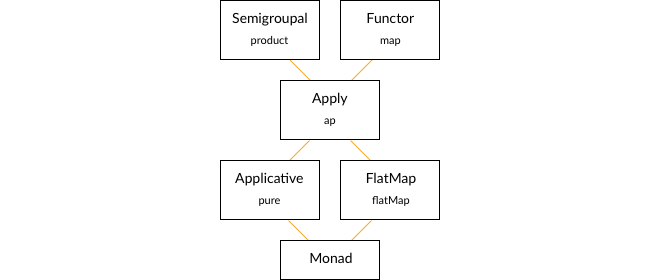

Figure 10: Monad type class hierarchy

Each type class in the hierarchy represents a particular set of sequencing semantics, introduces a set of characteristic methods, and defines the functionality of its supertypes in terms of them:

- every monad is an applicative;
- every applicative a semigroupal;
- and so on.

Because of the lawful nature of the relationships between the type classes, the inheritance relationships are constant across all instances of a type class. `Apply` defines `product` in terms of `ap` and `map`; `Monad` defines `product`, `ap`, and `map`, in terms of `pure` and `flatMap`.

To illustrate this let’s consider two hypothetical data types:

- `Foo` is a monad. It has an instance of the `Monad` type class that implements `pure` and `flatMap` and inherits standard definitions of `product`, `map`, and `ap`;
- `Bar` is an applicative functor. It has an instance of `Applicative` that implements `pure` and `ap` and inherits standard definitions of `product` and `map`.

What can we say about these two data types without knowing more about their implementation?

We know strictly more about `Foo` than `Bar`: `Monad` is a subtype of `Applicative`, so we can guarantee properties of `Foo` (namely `flatMap`) that we cannot guarantee with `Bar`. Conversely, we know that `Bar` may have a wider range of behaviours than `Foo`. It has fewer laws to obey (no `flatMap`), so it can implement behaviours that `Foo` cannot.

This demonstrates the classic trade-off of power (in the mathematical sense) versus constraint. The more constraints we place on a data type, the more guarantees we have about its behaviour, but the fewer behaviours we can model.

Monads happen to be a sweet spot in this trade-off. They are flexible enough to model a wide range of behaviours and restrictive enough to give strong guarantees about those behaviours. However, there are situations where monads aren’t the right tool for the job. Sometimes we want Thai food, and burritos just won’t satisfy.

Whereas monads impose a strict *sequencing* on the computations they model, applicatives and semigroupals impose no such restriction. This puts them in a different sweet spot in the hierarchy. We can use them to represent classes of parallel / independent computations that monads cannot.

We choose our semantics by choosing our data structures. If we choose a monad, we get strict sequencing. If we choose an applicative, we lose the ability to `flatMap`. This is the trade-off enforced by the consistency laws. So choose your types carefully!

## 11.6 Summary

While monads and functors are the most widely used sequencing data types we’ve covered in this book, semigroupals and applicatives are the most general. These type classes provide a generic mechanism to combine values and apply functions within a context, from which we can fashion monads and a variety of other combinators.

`Semigroupal` and `Applicative` are most commonly used as a means of combining independent values such as the results of validation rules. Cats provides the `Validated` type for this specific purpose, along with apply syntax as a convenient way to express the combination of rules.

We have almost covered all of the functional programming concepts on our agenda for this book. The next chapter covers `Traverse` and `Foldable`, two powerful type classes for converting between data types. After that we’ll look at several case studies that bring together all of the concepts from Part I.

# 12 Foldable and Traverse

In this chapter we’ll look at two type classes that capture iteration over collections:

- `Foldable` abstracts the familiar `foldLeft` and `foldRight` operations;
- `Traverse` is a higher-level abstraction that uses `Applicatives` to iterate with less pain than folding.

We’ll start by looking at `Foldable`, and then examine cases where folding becomes complex and `Traverse` becomes convenient.

## 12.1 Foldable

The `Foldable` type class captures the `foldLeft` and `foldRight` methods we’re used to in sequences like `Lists`, `Vectors`, and `Streams`. Using `Foldable`, we can write generic folds that work with a variety of sequence types. We can also invent new sequences and plug them into our code. `Foldable` gives us great use cases for `Monoids` and the `Eval` monad.

### 12.1.1 Folds and Folding

Let’s start with a quick recap of the general concept of folding. We supply an *accumulator* value and a *binary function* to combine it with each item in the sequence:

```scala
def show[A](list: List[A]): String =
  list.foldLeft("nil")((accum, item) => s"$item then $accum")
```

```scala
show(Nil)
// res0: String = "nil"

show(List(1, 2, 3))
// res1: String = "3 then 2 then 1 then nil"
```

The `foldLeft` method works recursively down the sequence. Our binary function is called repeatedly for each item, the result of each call becoming the accumulator for the next. When we reach the end of the sequence, the final accumulator becomes our final result.

Depending on the operation we’re performing, the order in which we fold may be important. Because of this there are two standard variants of fold:

- `foldLeft` traverses from “left” to “right” (start to finish);
- `foldRight` traverses from “right” to “left” (finish to start).

Figure 11 illustrates each direction.

[figure not shown]

Figure 11: Illustration of foldLeft and foldRight

`foldLeft` and `foldRight` are equivalent if our binary operation is associative. For example, we can sum a `List[Int]` by folding in either direction, using `0` as our accumulator and addition as our operation:

```scala
List(1, 2, 3).foldLeft(0)(_ + _)
// res2: Int = 6
List(1, 2, 3).foldRight(0)(_ + _)
// res3: Int = 6
```

If we provide a non-associative operator the order of evaluation makes a difference. For example, if we fold using subtraction, we get different results in each direction:

```scala
List(1, 2, 3).foldLeft(0)(_ - _)
// res4: Int = -6
List(1, 2, 3).foldRight(0)(_ - _)
// res5: Int = 2
```

### 12.1.2 Exercise: Reflecting on Folds

Try using `foldLeft` and `foldRight` with an empty list as the accumulator and `::` as the binary operator. What results do you get in each case?

Folding from left to right reverses the list:

```scala
List(1, 2, 3).foldLeft(List.empty[Int])((a, i) => i :: a)
// res6: List[Int] = List(3, 2, 1)
```

Folding right to left copies the list, leaving the order intact:

```scala
List(1, 2, 3).foldRight(List.empty[Int])((i, a) => i :: a)
// res7: List[Int] = List(1, 2, 3)
```

Note that we have to carefully specify the type of the accumulator to avoid a type error. We use `List.empty[Int]` to avoid inferring the accumulator type as `Nil.type` or `List[Nothing]`:

```scala
List(1, 2, 3).foldRight(Nil)(_ :: _)
// error:
// Found:    List[Int]
// Required: scala.collection.immutable.Nil.type
// List(1, 2, 3).foldRight(Nil)(_ :: _)
//                              ^^^^^^
```

### 12.1.3 Exercise: Scaf-fold-ing Other Methods

`foldLeft` and `foldRight` are very general methods. We can use them to implement many of the other high-level sequence operations we know. Prove this to yourself by implementing substitutes for `List's` `map`, `flatMap`, `filter`, and `sum` methods in terms of `foldRight`.

Here are the solutions:

```scala
def map[A, B](list: List[A])(func: A => B): List[B] =
  list.foldRight(List.empty[B]) { (item, accum) =>
    func(item) :: accum
  }
```

```scala
map(List(1, 2, 3))(_ * 2)
// res9: List[Int] = List(2, 4, 6)
```

```scala
def flatMap[A, B](list: List[A])(func: A => List[B]): List[B] =
  list.foldRight(List.empty[B]) { (item, accum) =>
    func(item) ::: accum
  }
```

```scala
flatMap(List(1, 2, 3))(a => List(a, a * 10, a * 100))
// res10: List[Int] = List(1, 10, 100, 2, 20, 200, 3, 30, 300)
```

```scala
def filter[A](list: List[A])(func: A => Boolean): List[A] =
  list.foldRight(List.empty[A]) { (item, accum) =>
    if(func(item)) item :: accum else accum
  }
```

```scala
filter(List(1, 2, 3))(_ % 2 == 1)
// res11: List[Int] = List(1, 3)
```

We’ve provided two definitions of `sum`, one using `scala.math.Numeric` (which recreates the built-in functionality accurately)…

```scala
import scala.math.Numeric

def sumWithNumeric[A](list: List[A])
      (implicit numeric: Numeric[A]): A =
  list.foldRight(numeric.zero)(numeric.plus)
```

```scala
sumWithNumeric(List(1, 2, 3))
// res12: Int = 6
```

and one using `cats.Monoid` (which is more appropriate to the content of this book):

```scala
import cats.Monoid

def sumWithMonoid[A](list: List[A])
      (implicit monoid: Monoid[A]): A =
  list.foldRight(monoid.empty)(monoid.combine)

import cats.instances.int._ // for Monoid
```

```scala
sumWithMonoid(List(1, 2, 3))
// res13: Int = 6
```

### 12.1.4 Foldable in Cats

Cats’ `Foldable` abstracts `foldLeft` and `foldRight` into a type class. Instances of `Foldable` define these two methods and inherit a host of derived methods. Cats provides out-of-the-box instances of `Foldable` for a handful of Scala data types: `List`, `Vector`, `LazyList`, and `Option`.

We can summon instances as usual using `Foldable.apply` and call their implementations of `foldLeft` directly. Here is an example using `List`:

```scala
import cats.Foldable
import cats.instances.list._ // for Foldable

val ints = List(1, 2, 3)
```

```scala
Foldable[List].foldLeft(ints, 0)(_ + _)
// res0: Int = 6
```

Other sequences like `Vector` and `LazyList` work in the same way. Here is an example using `Option`, which is treated like a sequence of zero or one elements:

```scala
import cats.instances.option._ // for Foldable

val maybeInt = Option(123)
```

```scala
Foldable[Option].foldLeft(maybeInt, 10)(_ * _)
// res1: Int = 1230
```

#### 12.1.4.1 Folding Right

`Foldable` defines `foldRight` differently to `foldLeft`, in terms of the `Eval` monad:

```scala
def foldRight[A, B](fa: F[A], lb: Eval[B])
                     (f: (A, Eval[B]) => Eval[B]): Eval[B]
```

Using `Eval` means folding is always *stack safe*, even when the collection’s default definition of `foldRight` is not. For example, the default implementation of `foldRight` for `LazyList` is not stack safe. The longer the lazy list, the larger the stack requirements for the fold. A sufficiently large lazy list will trigger a `StackOverflowError`:

```scala
import cats.Eval
import cats.Foldable

def bigData = (1 to 100000).to(LazyList)
```

```scala
bigData.foldRight(0L)(_ + _)
// java.lang.StackOverflowError ...
```

Using `Foldable` forces us to use stack safe operations, which fixes the overflow exception:

```scala
import cats.instances.lazyList._ // for Foldable
```

```scala
val eval: Eval[Long] =
  Foldable[LazyList].
    foldRight(bigData, Eval.now(0L)) { (num, eval) =>
      eval.map(_ + num)
    }
```

```scala
eval.value
// res3: Long = 5000050000L
```

*Stack Safety in the Standard Library*

Stack safety isn’t typically an issue when using the standard library. The most commonly used collection types, such as `List` and `Vector`, provide stack safe implementations of `foldRight`:

```scala
(1 to 100000).toList.foldRight(0L)(_ + _)
(1 to 100000).toVector.foldRight(0L)(_ + _)
// res4: Long = 5000050000L
```

#### 12.1.4.2 Folding with Monoids

`Foldable` provides us with a host of useful methods defined on top of `foldLeft`. Many of these are facsimiles of familiar methods from the standard library: `find`, `exists`, `forall`, `toList`, `isEmpty`, `nonEmpty`, and so on:

```scala
Foldable[Option].nonEmpty(Option(42))
// res5: Boolean = true

Foldable[List].find(List(1, 2, 3))(_ % 2 == 0)
// res6: Option[Int] = Some(value = 2)
```

In addition to these familiar methods, Cats provides two methods that make use of `Monoids`:

- `combineAll` (and its alias `fold`) combines all elements in the sequence using their `Monoid`;
- `foldMap` maps a user-supplied function over the sequence and combines the results using a `Monoid`.

For example, we can use `combineAll` to sum over a `List[Int]`:

```scala
import cats.instances.int._ // for Monoid
```

```scala
Foldable[List].combineAll(List(1, 2, 3))
// res7: Int = 6
```

Alternatively, we can use `foldMap` to convert each `Int` to a `String` and concatenate them:

```scala
import cats.instances.string._ // for Monoid
```

```scala
Foldable[List].foldMap(List(1, 2, 3))(_.toString)
// res8: String = "123"
```

Finally, we can compose `Foldables` to support deep traversal of nested sequences:

```scala
import cats.instances.vector._ // for Monoid

val ints = List(Vector(1, 2, 3), Vector(4, 5, 6))
```

```scala
(Foldable[List] compose Foldable[Vector]).combineAll(ints)
// res10: Int = 21
```

#### 12.1.4.3 Syntax for Foldable

Every method in `Foldable` is available in syntax form via [`cats.syntax.foldable`](http://typelevel.org/cats/api/cats/syntax/package$$foldable$). In each case, the first argument to the method on `Foldable` becomes the receiver of the method call:

```scala
import cats.syntax.foldable._ // for combineAll and foldMap
```

```scala
List(1, 2, 3).combineAll
// res11: Int = 6

List(1, 2, 3).foldMap(_.toString)
// res12: String = "123"
```

*Explicits over Implicits*

Remember that Scala will only use an instance of `Foldable` if the method isn’t explicitly available on the receiver. For example, the following code will use the version of `foldLeft` defined on `List`:

```scala
List(1, 2, 3).foldLeft(0)(_ + _)
// res13: Int = 6
```

whereas the following generic code will use `Foldable`:

```scala
def sum[F[_]: Foldable](values: F[Int]): Int =
  values.foldLeft(0)(_ + _)
```

We typically don’t need to worry about this distinction. It’s a feature! We call the method we want and the compiler uses a `Foldable` when needed to ensure our code works as expected. If we need a stack-safe implementation of `foldRight`, using `Eval` as the accumulator is enough to force the compiler to select the method from Cats.

## 12.2 Traverse

`foldLeft` and `foldRight` are flexible iteration methods but they require us to do a lot of work to define accumulators and combinator functions. The `Traverse` type class is a higher level tool that leverages `Applicatives` to provide a more convenient, more lawful, pattern for iteration.

### 12.2.1 Traversing with Futures

We can demonstrate `Traverse` using the `Future.traverse` and `Future.sequence` methods in the Scala standard library. These methods provide `Future`-specific implementations of the traverse pattern. As an example, suppose we have a list of server hostnames and a method to poll a host for its uptime:

```scala
import scala.concurrent._
import scala.concurrent.duration._
import scala.concurrent.ExecutionContext.Implicits.global

val hostnames = List(
  "alpha.example.com",
  "beta.example.com",
  "gamma.demo.com"
)

def getUptime(hostname: String): Future[Int] =
  Future(hostname.length * 60) // just for demonstration
```

Now, suppose we want to poll all of the hosts and collect all of their uptimes. We can’t simply `map` over `hostnames` because the result—a `List[Future[Int]]`—would contain more than one `Future`. We need to reduce the results to a single `Future` to get something we can block on. Let’s start by doing this manually using a fold:

```scala
val allUptimes: Future[List[Int]] =
  hostnames.foldLeft(Future(List.empty[Int])) {
    (accum, host) =>
      val uptime = getUptime(host)
      for {
        accum  <- accum
        uptime <- uptime
      } yield accum :+ uptime
  }
```

```scala
Await.result(allUptimes, 1.second)
// res0: List[Int] = List(1020, 960, 840)
```

Intuitively, we iterate over `hostnames`, call `func` for each item, and combine the results into a list. This sounds simple, but the code is fairly unwieldy because of the need to create and combine `Futures` at every iteration. We can improve on things greatly using `Future.traverse`, which is tailor-made for this pattern:

```scala
val allUptimes: Future[List[Int]] =
  Future.traverse(hostnames)(getUptime)
```

```scala
Await.result(allUptimes, 1.second)
// res2: List[Int] = List(1020, 960, 840)
```

This is much clearer and more concise—let’s see how it works. If we ignore distractions like `CanBuildFrom` and `ExecutionContext`, the implementation of `Future.traverse` in the standard library looks like this:

```scala
def traverse[A, B](values: List[A])
    (func: A => Future[B]): Future[List[B]] =
  values.foldLeft(Future(List.empty[B])) { (accum, host) =>
    val item = func(host)
    for {
      accum <- accum
      item  <- item
    } yield accum :+ item
  }
```

This is essentially the same as our example code above. `Future.traverse` is abstracting away the pain of folding and defining accumulators and combination functions. It gives us a clean high-level interface to do what we want:

- start with a `List[A]`;
- provide a function `A => Future[B]`;
- end up with a `Future[List[B]]`.

The standard library also provides another method, `Future.sequence`, that assumes we’re starting with a `List[Future[B]]` and don’t need to provide an identity function:

```scala
object Future {
  def sequence[B](futures: List[Future[B]]): Future[List[B]] =
    traverse(futures)(identity)

  // etc...
}
```

In this case the intuitive understanding is even simpler:

- start with a `List[Future[A]]`;
- end up with a `Future[List[A]]`.

`Future.traverse` and `Future.sequence` solve a very specific problem: they allow us to iterate over a sequence of `Futures` and accumulate a result. The simplified examples above only work with `Lists`, but the real `Future.traverse` and `Future.sequence` work with any standard Scala collection.

Cats’ `Traverse` type class generalises these patterns to work with any type of `Applicative`: `Future`, `Option`, `Validated`, and so on. We’ll approach `Traverse` in the next sections in two steps: first we’ll generalise over the `Applicative`, then we’ll generalise over the sequence type. We’ll end up with an extremely valuable tool that trivialises many operations involving sequences and other data types.

### 12.2.2 Traversing with Applicatives

If we squint, we’ll see that we can rewrite `traverse` in terms of an `Applicative`. Our accumulator from the example above:

```scala
Future(List.empty[Int])
```

is equivalent to `Applicative.pure`:

```scala
import cats.Applicative
import cats.instances.future._   // for Applicative
import cats.syntax.applicative._ // for pure

List.empty[Int].pure[Future]
```

Our combinator, which used to be this:

```scala
def oldCombine(
  accum : Future[List[Int]],
  host  : String
): Future[List[Int]] = {
  val uptime = getUptime(host)
  for {
    accum  <- accum
    uptime <- uptime
  } yield accum :+ uptime
}
```

is now equivalent to `Semigroupal.combine`:

```scala
import cats.syntax.apply._ // for mapN

// Combining accumulator and hostname using an Applicative:
def newCombine(accum: Future[List[Int]],
      host: String): Future[List[Int]] =
  (accum, getUptime(host)).mapN(_ :+ _)
```

By substituting these snippets back into the definition of `traverse` we can generalise it to to work with any `Applicative`:

```scala
def listTraverse[F[_]: Applicative, A, B]
      (list: List[A])(func: A => F[B]): F[List[B]] =
  list.foldLeft(List.empty[B].pure[F]) { (accum, item) =>
    (accum, func(item)).mapN(_ :+ _)
  }

def listSequence[F[_]: Applicative, B]
      (list: List[F[B]]): F[List[B]] =
  listTraverse(list)(identity)
```

We can use `listTraverse` to re-implement our uptime example:

```scala
val totalUptime = listTraverse(hostnames)(getUptime)
```

```scala
Await.result(totalUptime, 1.second)
// res5: List[Int] = List(1020, 960, 840)
```

or we can use it with other `Applicative` data types as shown in the following exercises.

#### 12.2.2.1 Exercise: Traversing with Vectors

What is the result of the following?

```scala
import cats.instances.vector._ // for Applicative

listSequence(List(Vector(1, 2), Vector(3, 4)))
```

The argument is of type `List[Vector[Int]]`, so we’re using the `Applicative` for `Vector` and the return type is going to be `Vector[List[Int]]`.

`Vector` is a monad, so its semigroupal `combine` function is based on `flatMap`. We’ll end up with a `Vector` of `Lists` of all the possible combinations of `List(1, 2)` and `List(3, 4)`:

```scala
listSequence(List(Vector(1, 2), Vector(3, 4)))
// res7: Vector[List[Int]] = Vector(
//   List(1, 3),
//   List(1, 4),
//   List(2, 3),
//   List(2, 4)
// )
```

What about a list of three parameters?

```scala
listSequence(List(Vector(1, 2), Vector(3, 4), Vector(5, 6)))
```

With three items in the input list, we end up with combinations of three `Ints`: one from the first item, one from the second, and one from the third:

```scala
listSequence(List(Vector(1, 2), Vector(3, 4), Vector(5, 6)))
// res9: Vector[List[Int]] = Vector(
//   List(1, 3, 5),
//   List(1, 3, 6),
//   List(1, 4, 5),
//   List(1, 4, 6),
//   List(2, 3, 5),
//   List(2, 3, 6),
//   List(2, 4, 5),
//   List(2, 4, 6)
// )
```

#### 12.2.2.2 Exercise: Traversing with Options

Here’s an example that uses `Options`:

```scala
import cats.instances.option._ // for Applicative

def process(inputs: List[Int]) =
  listTraverse(inputs)(n => if(n % 2 == 0) Some(n) else None)
```

What is the return type of this method? What does it produce for the following inputs?

```scala
process(List(2, 4, 6))
process(List(1, 2, 3))
```

The arguments to `listTraverse` are of types `List[Int]` and `Int => Option[Int]`, so the return type is `Option[List[Int]]`. Again, `Option` is a monad, so the semigroupal `combine` function follows from `flatMap`. The semantics are therefore fail-fast error handling: if all inputs are even, we get a list of outputs. Otherwise we get `None`:

```scala
process(List(2, 4, 6))
// res12: Option[List[Int]] = Some(value = List(2, 4, 6))
process(List(1, 2, 3))
// res13: Option[List[Int]] = None
```

#### 12.2.2.3 Exercise: Traversing with Validated

Finally, here is an example that uses `Validated`:

```scala
import cats.data.Validated
import cats.instances.list._ // for Monoid

type ErrorsOr[A] = Validated[List[String], A]

def process(inputs: List[Int]): ErrorsOr[List[Int]] =
  listTraverse(inputs) { n =>
    if(n % 2 == 0) {
      Validated.valid(n)
    } else {
      Validated.invalid(List(s"$n is not even"))
    }
  }
```

What does this method produce for the following inputs?

```scala
process(List(2, 4, 6))
process(List(1, 2, 3))
```

The return type here is `ErrorsOr[List[Int]]`, which expands to `Validated[List[String], List[Int]]`. The semantics for semigroupal `combine` on validated are accumulating error handling, so the result is either a list of even `Ints`, or a list of errors detailing which `Ints` failed the test:

```scala
process(List(2, 4, 6))
// res17: Validated[List[String], List[Int]] = Valid(a = List(2, 4, 6))
process(List(1, 2, 3))
// res18: Validated[List[String], List[Int]] = Invalid(
//   e = List("1 is not even", "3 is not even")
// )
```

### 12.2.3 Traverse in Cats

Our `listTraverse` and `listSequence` methods work with any type of `Applicative`, but they only work with one type of sequence: `List`. We can generalise over different sequence types using a type class, which brings us to Cats’ `Traverse`. Here’s the abbreviated definition:

```scala
package cats

trait Traverse[F[_]] {
  def traverse[G[_]: Applicative, A, B]
      (inputs: F[A])(func: A => G[B]): G[F[B]]

  def sequence[G[_]: Applicative, B]
      (inputs: F[G[B]]): G[F[B]] =
    traverse(inputs)(identity)
}
```

Cats provides instances of `Traverse` for `List`, `Vector`, `Stream`, `Option`, `Either`, and a variety of other types. We can summon instances as usual using `Traverse.apply` and use the `traverse` and `sequence` methods as described in the previous section:

```scala
import cats.Traverse
import cats.instances.future._ // for Applicative
import cats.instances.list._   // for Traverse

val totalUptime: Future[List[Int]] =
  Traverse[List].traverse(hostnames)(getUptime)
```

```scala
Await.result(totalUptime, 1.second)
// res0: List[Int] = List(1020, 960, 840)
```

```scala
val numbers = List(Future(1), Future(2), Future(3))

val numbers2: Future[List[Int]] =
  Traverse[List].sequence(numbers)
```

```scala
Await.result(numbers2, 1.second)
// res1: List[Int] = List(1, 2, 3)
```

There are also syntax versions of the methods, imported via [`cats.syntax.traverse`](http://typelevel.org/cats/api/cats/syntax/package$$traverse$):

```scala
import cats.syntax.traverse._ // for sequence and traverse
```

```scala
val numbers3 = hostnames.traverse(getUptime)
// numbers3: Future[List[Int]] = Future(Success(List(1020, 960, 840)))
val numbers4 = numbers.sequence
// numbers4: Future[List[Int]] = Future(Success(List(1, 2, 3)))

Await.result(numbers3, 1.second)
// res2: List[Int] = List(1020, 960, 840)
Await.result(numbers4, 1.second)
// res3: List[Int] = List(1, 2, 3)
```

As you can see, this is much more compact and readable than the `foldLeft` code we started with earlier this chapter!

## 12.3 Summary

In this chapter we were introduced to `Foldable` and `Traverse`, two type classes for iterating over sequences.

`Foldable` abstracts the `foldLeft` and `foldRight` methods we know from collections in the standard library. It adds stack-safe implementations of these methods to a handful of extra data types, and defines a host of situationally useful additions. That said, `Foldable` doesn’t introduce much that we didn’t already know.

The real power comes from `Traverse`, which abstracts and generalises the `traverse` and `sequence` methods we know from `Future`. Using these methods we can turn an `F[G[A]]` into a `G[F[A]]` for any `F` with an instance of `Traverse` and any `G` with an instance of `Applicative`. In terms of the reduction we get in lines of code, `Traverse` is one of the most powerful patterns in this book. We can reduce `folds` of many lines down to a single `foo.traverse`.

…and with that, we’ve finished all of the theory in this book. There’s plenty more to come, though, as we put everything we’ve learned into practice in a series of in-depth case studies in Part II!